# Another shot

## 0. Packages

Installing the required packages from CRAN:

```r
required <- c("car", "dplyr", "lubridate", "magrittr", "purrr", "readxl",
              "stringr", "survival", "tibble", "tidyr", "writexl")
installed <- row.names(installed.packages())
to_install <- setdiff(required, installed)
if (length(to_install)) install.packages(to_install)
```

Plus `C306` from GitHub:

```r
if (! "C306" %in% installed) {
  if (! "remotes" %in% installed) install.packages("remotes")
  remotes::install_github("lampk/C306")
}
```

Loading packages for interactive use:

```r
library(magrittr)
library(dplyr)
library(purrr)
library(tidyr)
library(lubridate)
library(tibble)
library(stringr)
library(C306)
library(survival)
#library(huxtable)
```

### Utilitary functions

Theh following functions converts a “Yes/No” variable into a boolean variable, dealing with missing values properly:

```r
yesno2bool <- function(x) na_if(x, "NA") == "Yes"
```

A safe `as_data.frame()` function:

```r
as_data.frame <- function(...) as.data.frame(..., stringsAsFactors = FALSE)
```

A `left_join()` by `PatientNo`:

```r
leftjoin <- function(...) dplyr::left_join(..., by = "PatientNo")
```

## 1. Reading and putting the data in shape

### Reading data

The data are in this file:

```r
data_file <- "19-8-2019-CTU16HN_Data.xls.xlsx"
```

The sheets that we are interested in are the following ones:

```r
sheets <- c("ADM", "AIR", "APAC", "DAILY1n2", "ENR", "FINISH", "FU", "FU_DAY90", "MICBLD")
```

Reading all the sheets of this file and transforming the dates:

```r
data <- sheets %>%
  lapply(readxl::read_excel, path = data_file) %>%
  lapply(function(x) mutate_if(x, function(y) "POSIXct" %in% class(y), as.Date)) %>%
  setNames(sheets)
```

#### Tyding data

The data about discharge:

```r
data$FINISH %<>%
  select(PatientNo, IsCompleted, IsAgree, HosDate, ICUDate, OutCome, HosSame) %>%
  rename(ICUDateFINISH = ICUDate) %>%
  distinct()
```

Where:

`IsComplete == 1`: completed until discharge or death

`IsAgree == "Yes"`: agree to use data for those who didn’t complete.

`HosDate`: date of discharge

`ICUDate`: date of this study ward discharge

`OutCome`: death or not

The data about admission:

```r
data$ADM %<>%
  select(PatientNo, HospitalDate, NKQ, Tetanus, Pneumonia, Sepsis, Septic, CNS,
         COPD, CVA, Myo, SpOther, DiaCo, DiaDa, Mode, CongI_III, Peri, Cere, Deme,
         Chro, Conn, Peptic, Hemi, ModeSeve, Meta, AIDS, AnyMa, CongIV, Elective,
         Emergency, Source, Mild, Seve, ICUDate) %>%
  rename(ICUDateADM = ICUDate) %>%
  distinct()
```

The following function corrects the names of the bacteria:

```r
correct_names <- function(x) {
  x %>%
    str_to_sentence() %>%
    str_replace("Staph epidermidis"                 , "Staphylococcus epidermidis") %>%
    str_replace("Staph haemolyticus"                , "Staphylococcus haemolyticus") %>%
    str_replace("S.marcescens"                      , "Serratia marcescens") %>%
    str_replace("Elizabethkingie"                   , "Elizabethkingia") %>%
    str_replace("Enterobacter aerogenes"            , "Klebsiella aerogenes") %>%
    str_replace("Proteus mirasilis"                 , "Proteus mirabilis") %>%
    str_replace("Staphylococcin epidermidis"        , "Staphylococcus epidermidis") %>%
    str_replace("Staphylococcs xylosus"             , "Staphylococcus xylosus") %>%
    str_replace("Stenotrophomonas malto"            , "Stenotrophomonas maltophilia") %>%
    str_replace("Enterococcus fecalis"              , "Enterococcus faecalis") %>%
    str_replace("Stenotrophomonas maltophiliaphilia", "Stenotrophomonas maltophilia") %>%
    str_replace(" \\(-\\)", "")
}
```

Blood microbiology:

```r
data$MICBLD %<>%
  select(PatientNo, HAIDate, OrganismsNo, Iden1, Iden2, OtherIden1, OtherIden2,
         IsOxac1, IsESBL1, IsColistin1, IsOxac2, IsESBL2, IsColistin2) %>%
  mutate_at(vars(IsOxac1, IsESBL1, IsColistin1, IsOxac2, IsESBL2, IsColistin2), yesno2bool) %>%
  mutate_at(vars(OtherIden1, OtherIden2), correct_names) %>%
  mutate_at(vars(Iden1, Iden2), recode, `1` = "Pseudomonas aeruginosa",
                                        `2` = "Klebsiella pneumoniae",
                                        `3` = "Staphylococcus aureus",
                                        `4` = "Acinetobacter baumanii",
                                        `5` = "Escherichia coli",
                                        `6` = "otherpath") %>%
  mutate(Iden1 = ifelse(Iden1 == "otherpath", OtherIden1, Iden1),
         Iden2 = ifelse(Iden2 == "otherpath", OtherIden2, Iden2),
         condition = Iden1 < Iden2,
         Iden1b = ifelse(condition, Iden1, Iden2),
         Iden2b = ifelse(condition, Iden2, Iden1)) %>%
  unite("pathogens", Iden1b, Iden2b, sep = ", ") %>%
  mutate(pathogens = ifelse(pathogens == "NA, NA", Iden1, pathogens)) %>%
  select(-OtherIden1, -OtherIden2, -condition) %>%
  distinct()
```

`HAIDate`: date of sampling

Daily monitoring:

```r
data$DAILY1n2 %<>%
  select(PatientNo, CVCCount, VSDate, Arterial, TempMax, TempMin) %>%
  mutate_at(vars(Arterial), yesno2bool) %>%
  distinct()
```

`CVCCount`: number of central venous catheters.

Patient information:

```r
data$ENR %<>%
  select(PatientNo, Sex, Age, YOB, RandDate) %>%
  distinct()
```

Ventilation:

```r
data$AIR %<>%
  select(PatientNo, IsTrach, TrachDate) %>%
  distinct()
```

Apache code variables:

```r
data$APAC %<>%
  select(PatientNo, HbA1c, Sodium, Potassium, Creatinine, Haematocrit, BloodCell,
         Systolic, Diastolic, PuHightest, PuLowest, ResHightest, ResLowest, FiO2,
         PaO2, PaCO2, HCO3, ArterialpH, GlasgowScore, Motor, Verbal, Eyes, Total) %>%
  distinct()
```

Follow-up at 28 days:

```r
data$FU %<>%
  select(PatientNo, DeathDate28, Status28, Date28) %>% # We probably don't need this any more for now
  distinct()
```

Follow-up at 90 days:

```r
data$FU_DAY90 %<>%
  select(PatientNo, DeathDate90, Status90, Date90) %>% # We probably don't need this any more for now
  distinct()
```

### Microbiology variables (MICBLD)

#### Adding episode variable

The following function adds the episode variable:

```r
add_episode <- function(x) {
# it's not clear why the filter() / right_join() doesn't work here and has to be
# after the group_modify() call below.
  x %>%
#    filter(OrganismsNo > 0) %>%
    add_column(episode = cumsum(c(1, ! (diff(.$HAIDate) < 2 | (diff(.$HAIDate) < 3 & diff(as.integer(as.factor(.$pathogens))) < 1)))))# %>%
#    right_join(select(x, PatientNo, HAIDate))
}
```

Let’s try it:

```r
data$MICBLD %>%
  filter(OrganismsNo > 0) %>%
  arrange(HAIDate) %>%
  filter(PatientNo == "020-526") %>%
  add_episode() %>%
  select(-starts_with("Is"))
```

```
## # A tibble: 4 x 7
##   PatientNo HAIDate    OrganismsNo Iden1                  Iden2                 pathogens                                     episode
##   <chr>     <date>           <dbl> <chr>                  <chr>                 <chr>                                           <dbl>
## 1 020-526   2018-06-25           1 Burkholderia seminalis <NA>                  Burkholderia seminalis                              1
## 2 020-526   2018-07-02           1 Acinetobacter baumanii <NA>                  Acinetobacter baumanii                              2
## 3 020-526   2018-07-04           1 Acinetobacter baumanii <NA>                  Acinetobacter baumanii                              2
## 4 020-526   2018-07-05           2 Acinetobacter baumanii Klebsiella pneumoniae Acinetobacter baumanii, Klebsiella pneumoniae       2
```

Let’s add it to the whole data set:

```r
data$MICBLD %<>%
  filter(OrganismsNo > 0) %>%
  arrange(HAIDate) %>%
  group_by(PatientNo) %>%
  group_modify(~ add_episode(.x)) %>%
  ungroup() %>%
  right_join(select(data$MICBLD, PatientNo, HAIDate), c("PatientNo", "HAIDate"))
```

#### Other variables

Patients with BSI, showing the date of the first BSI episode:

```r
first_bsi <- data$MICBLD %>%
  filter(OrganismsNo > 0) %>%
  arrange(HAIDate) %>%
  group_by(PatientNo) %>%
  summarise(first_BSI = first(HAIDate))
```

Numbers of BSI episodes:

```r
nb_bsi <- data$MICBLD %>%
  filter(OrganismsNo > 0) %>%
  group_by(PatientNo) %>%
  summarise(nb_bsi = length(unique(episode)))
```

Number of pathogens in the first episode of BSI:

```r
nb_path_bsi1 <- data$MICBLD %>%
  filter(episode < 2) %>%
  group_by(PatientNo) %>%
  summarise(nb_path_bsi1 = length(unique(first(strsplit(paste(unlist(pathogens), collapse = ", "), ", ")))))
```

### Daily monitoring variables (DAILY1n2)

Patients with catheter:

```r
had_catheter <- data$DAILY1n2 %>%
  group_by(PatientNo) %>%
  summarise(had_catheter = any(CVCCount > 0))
```

Patients with arterial line during ICU stay:

```r
had_arterial <- data$DAILY1n2 %>%
  group_by(PatientNo) %>%
  summarise(had_arterial = any(Arterial))
```

Patients at risk of CLBSI (i.e. with central line placement for at least 2 consecutive days):

```r
clbsi_risk <- data$DAILY1n2 %>%
  filter(CVCCount > 0) %>%
  group_by(PatientNo) %>%
  summarise(CLBSI_risk = ifelse(length(VSDate) > 1, any(diff(VSDate) < 2), FALSE))
```

Patients with CLBSI

```r
clbsi <- leftjoin(first_bsi, data$DAILY1n2) %>%
  filter(first_BSI - VSDate < 6, CVCCount > 0) %>%
  group_by(PatientNo) %>%
  summarise(CLBSI = ifelse(length(VSDate) > 1, any(diff(VSDate) < 2), FALSE))
```

Patients at risk of ALBSI:

```r
albsi_risk <- data$DAILY1n2 %>%
  filter(Arterial) %>%
  group_by(PatientNo) %>%
  summarise(ALBSI_risk = ifelse(length(VSDate) > 1, any(diff(VSDate) < 2), FALSE))
```

Patients with ALBSI:

```r
albsi <- leftjoin(first_bsi, data$DAILY1n2) %>%
  filter(first_BSI - VSDate < 6, Arterial) %>%
  group_by(PatientNo) %>%
  summarise(ALBSI = ifelse(length(VSDate) > 1, any(diff(VSDate) < 2), FALSE))
```

Total number of Central line days:

```r
nb_cl_days <- leftjoin(data$DAILY1n2, first_bsi) %>%
  filter(is.na(first_BSI) | VSDate < first_BSI, CVCCount > 0) %>%
  group_by(PatientNo) %>%
  tally() %>%
  rename(nb_cl_days = n)
```

Total number of arterial line days:

```r
nb_al_days <- leftjoin(data$DAILY1n2, first_bsi) %>%
  filter(is.na(first_BSI) | VSDate < first_BSI, Arterial) %>%
  group_by(PatientNo) %>%
  tally() %>%
  rename(nb_al_days = n)
```

### Other variables

Need to be calculated now because the calculation of APACHE-II need the age variable that is calculated here.

```r
data2 <- c(data[setdiff(names(data), c("DAILY1n2", "MICBLD"))],
           list(first_bsi, clbsi_risk, clbsi, albsi_risk, albsi, nb_cl_days,
                nb_al_days, nb_bsi, nb_path_bsi1, had_catheter, had_arterial)) %>%
  reduce(leftjoin) %>%
  mutate_at(c("CLBSI_risk", "CLBSI", "ALBSI_risk", "ALBSI", "had_catheter", "had_arterial"),
            replace_na, FALSE) %>%
  mutate_at(c("nb_cl_days", "nb_al_days", "nb_bsi"), replace_na, 0) %>%
  mutate_at(vars(IsAgree, Myo, DiaCo, DiaDa, Mode, CongI_III, Peri, Cere, Deme,
                 Chro, Conn, Peptic, Hemi, ModeSeve, Meta, AIDS, AnyMa, CongIV,
                 Elective, Emergency, Mild, Seve, IsTrach), yesno2bool) %>%
  mutate(
# at risk of hopital acquired blood stream infection:
         habsi_risk   = replace_na(HosDate - HospitalDate > 1, FALSE),
# hospitals:
         hospital     = recode(sub("-.*$", "", PatientNo),
                                 `003` = "HTD",
                                 `020` = "NHTD",
                                 `103` = "BVTV"),
# ages:
         age          = ifelse(is.na(Age),
                               round(as.numeric(RandDate - ymd(paste(YOB, "0101"))) / 365),
                               Age),
# HABSI:
         habsi        = nb_bsi > 0,
# recode NKQ:
         NKQ          = recode(NKQ, `1` = "tracheostomy", `2` = "mouth"),
# tracheostomy:
         tracheostomy = NKQ == "mouth" | IsTrach,
         tracheostomy = ifelse(habsi, tracheostomy & TrachDate < first_BSI, tracheostomy),
# sepsis:
         sepsis = Sepsis | Septic,
# comorbidity of diabetes:
         dia_co       = DiaCo | DiaDa | HbA1c >= 6.5,
# durations:
         rand2icu     = ICUDateFINISH - RandDate,
         rand2hos     = HosDate - RandDate,
         adm2icu      = ICUDateFINISH - HospitalDate,
         adm2hos      = HosDate - HospitalDate,
         ICUstay      = ICUDateFINISH - ICUDateADM,
# time of BSI potential event:
         time2bsi     = ifelse(is.na(first_BSI), ICUDateFINISH, first_BSI) - as.numeric(RandDate),
# death at hospital discharge:
#         deathHOSdis  = OutCome < 3,
# death at ICU discharge:
#         deathICUdis  = deathHOSdis & HosDate == ICUDateFINISH,
# death 28 days:
#         death28days  = Status28 == "Died",
# death 90 days:
#         death90days  = Status90 == "Died",
# other pathogen:
         otherpath    = ! is.na(SpOther),
# transfer from other hospital:
         otherhosp    = Source == "Other hospital")
```

Nothing to worry about the 8 failed to parse.

### Adding Charlson scores

Computing and adding the Charlson scores to `data2`:

```r
charlson <- data2 %>%
  select(PatientNo, Myo, CongI_III, Peri, Cere, Deme, Chro, Conn, Peptic,
         Mild, DiaCo, Hemi, ModeSeve, DiaDa, AnyMa, Mode, Meta, AIDS) %>%
  mutate_all(replace_na, FALSE) %>%
  mutate_if(is.logical, as.integer) %>%
  mutate_at(vars(Hemi, ModeSeve, DiaDa, AnyMa), function(x) 2 * x) %>%
  mutate_at(vars(Meta, AIDS), function(x) 6 * x) %>%
  mutate(Mode         = 3 * Mode) %>%
  mutate(charlson     = select_if(., is.numeric) %>% rowSums())
```

Let’s compare with Thinh:

```r
charlson_trinh <- readRDS("charlson_score.rds")

setdiff(charlson$PatientNo, charlson_trinh$PatientNo)
```

```
## character(0)
```

```r
setdiff(charlson_trinh$PatientNo, charlson$PatientNo)
```

```
## character(0)
```

```r
marc <- charlson %>%
  arrange(PatientNo) %>%
  select(-PatientNo) %>%
  mutate_all(as.integer)

trinh <- charlson_trinh %>%
  arrange(PatientNo) %>%
  select(-PatientNo) %>%
  mutate_all(as.integer)

any(! unlist(map2(marc, trinh, identical)))
```

```
## [1] FALSE
```

```r
charlson2 <- charlson %>%
  mutate_at(vars(charlson), ~ cut(.x, c(-Inf, 0, 2, 4, Inf)) %>% as.character()) %>%
  select(PatientNo, charlson)
```

Let’s add to `data2`:

```r
data2 %<>% leftjoin(charlson2)
```

### Adding APACHE-II scores

The Apache-II Score provides an estimate of ICU mortality based on a number of laboratory values and patient signs taking both acute and chronic disease into account.

**Note:** The data used should relate to the 24 hours prior to randomisation and the worst (highest scoring) recorded values should be used.

This function below computes score functions:

```r
make_score_functions <- function(scores, values) {
  function(x) scores[cut(x, c(-Inf, values, +Inf), right = FALSE)]
}
```

The parameters values for the score functions:

```r
apache_physio <- list(
  temp = list(
    scores = c(4:0, 1, 3, 4),
    values = c(30, 32, 34, 36, 38.5, 39, 41)),
  bp = list(
    scores = c(4, 2, 0, 2:4),
    values = c(50, 70, 110, 130, 160)),
  hr = list(
    scores = c(4, 3, 2, 0, 2, 3, 4),
    values = c(40, 55, 70, 110, 140, 180)),
  rr = list(
    scores = c(4, 2, 1, 0, 1, 3, 4),
    values = c(6, 10, 12, 25, 35, 50)),
  pao2 = list(
    scores = c(4, 3, 1, 0),
    values = c(55, 61, 70)),
  aa_gradient = list(
    scores = c(0, 2:4),
    values = c(200, 350, 500)),
  ph = list(
    scores = c(4, 3, 2, 0, 1, 3, 4),
    values = c(7.15, 7.25, 7.33, 7.5, 7.6, 7.7)),
  hco3 = list(
    scores = c(4, 3, 2, 0, 1, 3, 4),
    values = c(15, 18, 23, 32, 41, 52)),
  na = list(
    scores = c(4:2, 0:4),
    values = c(111, 120, 130, 150, 155, 160, 180)),
  k = list(
    scores = c(4, 2:0, 1, 3, 4),
    values = c(2.5, 3, 3.5, 5.5, 6, 7)),
  creatinine = list(
    scores = c(2, 0, 2:4),
    values = c(0.6, 1.5, 2, 3.5)),
  hematocrit = list(
    scores = c(4, 2, 0:2, 4),
    values = c(20, 30, 46, 50, 60)),
  wbc = list(
    scores = c(4, 2, 0:2, 4),
    values = c(1, 3, 15, 20, 40)),
  age = list(
    scores = rev(c(0, 2, 3, 5, 6)),
    values = c(44, 54, 64, 74)))
```

Let’s generate the score functions:

```r
score_fcts <- setNames(lapply(apache_physio,
                              function(x) make_score_functions(x$scores, x$values)),
                       names(apache_physio))
```

Let’s see an example:

```r
head(score_fcts$temp(data$DAILY1n2$TempMax), 100)
```

```
##   [1]  3  1  0  0  0  0  0  0  0  3  1  3  1  0  0  1  3  3  3  3  4  0  0  0  0  0  0  0  3  3  1  3  0  0  0  0  0  0  1  0  0  0  0  1  0  0  1  4  1  3  3  0  0
##  [54]  0  3  0  0  0  0  0  3  0  0  3  3  1  1  1  3  1  1  3  3  3  0  0  3  3  3  3  0  0  1  1  1  0 NA  3  3  1  1  1  0  0  0  0  0  0  0  0
```

Computing and adding the apache scores to `data2`:

```r
apache <- data$APAC %>%
  leftjoin(select(data2, PatientNo, age, RandDate, Mode, CongIV, Seve, AIDS, Elective, Emergency)) %>%
  left_join(select(data$DAILY1n2, PatientNo, VSDate, TempMax, TempMin), c("PatientNo", "RandDate" = "VSDate")) %>%
  mutate(a = score_fcts$temp(TempMax),
         b = score_fcts$temp(TempMin),
         temp_score = ifelse(a < b, b, a),
         map_score  = score_fcts$bp((2 * Diastolic + Systolic) / 3),
         a = score_fcts$hr(PuHightest),
         b = score_fcts$hr(PuLowest),
         hr_score = ifelse(a < b, b, a),
         a = score_fcts$rr(ResHightest),
         b = score_fcts$rr(ResLowest),
         rr_score = ifelse(a < b, b, a),

         PaCO2 = ifelse(is.na(PaCO2), HCO3 / (0.03 * 10 ^ (ArterialpH - 6.1)), PaCO2),
         aa_gradient = 713 * FiO2 - PaCO2 / .8 - PaO2,
#         a_score = ifelse(is.na(aa_gradient) | FiO2 < .5, score_fcts$pao2(PaO2), score_fcts$aa_gradient(aa_gradient)),
         a_score = ifelse(is.na(FiO2) | FiO2 < .5, score_fcts$pao2(PaO2), score_fcts$aa_gradient(aa_gradient)),

         ph_score = ifelse(is.na(ArterialpH), score_fcts$hco3(HCO3), score_fcts$ph(ArterialpH)),

         na_score = score_fcts$na(Sodium),
         k_score = score_fcts$k(Potassium),
         creatinine_score = score_fcts$creatinine(Creatinine),
         hematocrit_score = score_fcts$hematocrit(Haematocrit),
         wbc_score = score_fcts$wbc(BloodCell),
         gcs_score = ifelse(is.na(GlasgowScore),
                            NA,
                            15 - ifelse(GlasgowScore == "Preintubation",
                                        ifelse(is.na(Motor) | is.na(Verbal) | is.na(Eyes) |
                                                 Motor == 0 | Verbal == 0   | Eyes == 0   |
                                                 Motor == 9 | Verbal == 9   | Eyes == 9,
                                               Total,
                                               Motor + Verbal + Eyes),
                                        15)),
#         gcs_score = 15 - ifelse(GlasgowScore == "Preintubation",
#                                 ifelse(is.na(Motor) | is.na(Verbal) | is.na(Eyes) |
#                                          Motor == 0 | Verbal == 0   | Eyes == 0   |
#                                          Motor == 9 | Verbal == 9   | Eyes == 9,
#                                        Total,
#                                        Motor + Verbal + Eyes),
#                                 15),
         age_score = score_fcts$age(age),
         c_score = ifelse(Mode + CongIV + Seve + AIDS < 1,
                          0,
                          ifelse(Emergency,
                                 5,
                                 ifelse(Elective, 2, 5)))) %>%
  select(PatientNo, TempMin, TempMax, temp_score, map_score, hr_score, rr_score, a_score, ph_score, na_score, k_score,
         creatinine_score, hematocrit_score, wbc_score, gcs_score, age_score, c_score) %>%
  mutate_all(replace_na, 0) %>%
  mutate(apache = temp_score + map_score + hr_score + rr_score + a_score + ph_score + na_score + k_score +
                     creatinine_score + hematocrit_score + wbc_score + gcs_score + age_score + c_score) %>%
  select(-TempMin, -TempMax)
```

Let’s compare with Trinh:

```r
apache_trinh <- readRDS("apache.ii_score.rds") %>%
  mutate_if(is.factor, as.character)

setdiff(apache$PatientNo, apache_trinh$PatientNo)
```

```
## character(0)
```

```r
setdiff(apache_trinh$PatientNo, apache$PatientNo)
```

```
## character(0)
```

```r
marc <- apache %>%
  arrange(PatientNo) %>%
  select(-PatientNo, -apache, -a_score, -ph_score)

trinh <- apache_trinh %>%
  arrange(PatientNo) %>%
  select(-PatientNo, -aapo2, -pao2, -ph, -hco3, -total_score)

trinh[] <- lapply(trinh, function(x) {x[which(is.infinite(x))] <- 0; x})

unlist(map2(marc, trinh, identical))
```

```
##       temp_score        map_score         hr_score         rr_score         na_score          k_score creatinine_score hematocrit_score        wbc_score
##            FALSE             TRUE             TRUE             TRUE             TRUE             TRUE             TRUE             TRUE             TRUE
##        gcs_score        age_score          c_score
##            FALSE            FALSE            FALSE
```

Let’s add the APACHE-II scores from Trinh:

```r
data2 %<>% leftjoin(select(apache_trinh, PatientNo, total_score) %>% rename(apache = total_score))
```

### Adding mortalities from Trinh

```r
data2 <- readRDS("death_day.full.rds") %>%
  mutate(death28 = Event > 0  & DOD < 29,
         death90 = Event > 0  & DOD < 91) %>%
  select(PatientNo, death28, death90, DOD) %>%
  leftjoin(select(readRDS("icu_mortality.full.rds"), -IsTetanus)) %>%
  rename(deathICU = IsDeath) %>%
  leftjoin(data2, .) %>%
  mutate(VARI = as.character(VARI) == "VARI")
```

Note that there are 6 missing values in `DOD`. Adding `VAT` and `VAP` from Trinh too.

```r
data2 <- readRDS("protocol.VARI.rds") %>%
  select(PatientNo, VAP, VAT) %>%
  leftjoin(data2, .) %>%
  mutate_at(vars(VAP, VAT), replace_na, FALSE)
```

Note here that Trinh’s data have 521 observations only. Missing values were replaced by `FALSE`.

### Filtering the data set

Non-eligible patients:

```r
non_eligible_IDs <- c("020-007", "020-012", "020-063", "003-089", "003-053", "003-110")
```

```r
data2 %<>% filter(! (IsCompleted > 1 & ! IsAgree),
                  ! PatientNo %in% non_eligible_IDs)
```

### Cleaning the data set

```r
data2 %<>%
  select(PatientNo, hospital, Sex, age, otherhosp, NKQ, tracheostomy,
         CLBSI_risk, ALBSI_risk, apache, charlson, Tetanus, Pneumonia, sepsis,
         CNS, COPD, CVA, Myo, otherpath, dia_co, Mode, rand2icu, rand2hos, adm2icu,
         adm2hos, time2bsi, had_catheter, nb_cl_days, had_arterial, nb_al_days, habsi,
         habsi_risk, CLBSI_risk, CLBSI, ALBSI_risk, ALBSI, DOD, death28, death90, deathICU,
         VARI, nb_bsi, nb_path_bsi1, VAT, VAP) %>%
  mutate_if(is.numeric, as.integer)
```

Saving to disk:

```r
write.csv(data2, "bsi.csv", quote = FALSE, row.names = FALSE)
```

and

```r
writexl::write_xlsx(data2, "bsi.xlsx")
```

## 2. Derivation of Table 1 on demographics

### Utilitary functions

```r
remove_boolean <- function(x) {
  sel <- which(x[, 1] == "- TRUE")
  x[sel - 2, c(3, 5, 7)] <- x[sel, c(3, 5, 7)]
  x[-c(sel - 1, sel), ]
}
```

```r
add_cause_admission <- function(x, causes) {
  sel <- which(x[, 1] == causes[1])
  nb <- x[sel, ]
  nb[1] <- "Causes of admission"
  nb[c(3, 5, 7)] <- ""
  x[which(x[, 1] %in% causes), 2] <- ""
  x <- rbind(x[1:(sel - 1), ], nb, x[sel:nrow(x), ])
  for(i in causes) x[, 1] <- sub(i, paste("-", i), x[, 1])
  x
}
```

```r
patient_day <- function(g, v, df) {
  df %>%
    group_by({{ g }}) %>%
    summarise(pd = sum({{ v }}, na.rm = TRUE)) %>%
    pivot_wider(names_from = 1, values_from = pd) %>%
    unlist() %>%
    rev(.) %>%
    c(sum(.)) %>%
    inset(c("patient-day", rep("", 6)), c(2, 4, 6), .)
}
```

```r
mean_ci <- function(x) {
  m <- lm(x ~ 1)
  paste0(round(coef(m), 2), " (", paste(round(confint(m), 2), collapse = ", "), ")")
}
```

Let’s try it:

```r
mean_ci(data2$nb_cl_days)
```

```
## [1] "6.22 (5.48, 6.97)"
```

```r
day_per_patient <- function(g, v, data) {
  data %>%
    group_by({{ g }}) %>%
    summarise(a = mean_ci({{ v }})) %>%
    pivot_wider(names_from = 1, values_from = a) %>%
    unlist() %>%
    rev(.) %>%
    c(mean_ci(unlist(select(data, {{ v }})))) %>%
    inset(c("day/patient", rep("", 6)), c(3, 5, 7), .) %>%
    inset(c(2, 4, 6), group_by(data, {{ g }}) %>%
                        tally() %>%
                        pull() %>%
                        rev() %>%
                        c(nrow(data)))
}
```

The following function generate Table 1 for a given group `x`:

```r
make_table_1 <- function(x) {
  new_x <- paste0(x, 2)
  data2[["new_x"]] <- ifelse(data2[[x]], x, paste0("non-", x))
  data2 %>%
    mutate_at(c("rand2icu", "rand2hos", "adm2icu", "adm2hos"), as.integer) %>%
    sstable.baseline(hospital + Sex + age + otherhosp + NKQ + tracheostomy +
                       CLBSI_risk + ALBSI_risk + apache + charlson + Tetanus +
                       Pneumonia + sepsis + CNS + COPD + CVA + Myo + otherpath +
                       dia_co + Mode + rand2icu + rand2hos + adm2icu + adm2hos +
                       had_catheter + nb_cl_days + had_arterial + nb_al_days +
                       habsi + deathICU + death28 + death90 ~ new_x,
                     data = ., pooledGroup = TRUE, digits = 1, flextable = FALSE) %>%
    use_series("table") %>%
    as_data.frame() %>%
    remove_boolean() %>%
    add_cause_admission(c("Tetanus", "Pneumonia", "sepsis", "CNS", "COPD", "CVA", "Myo", "otherpath")) %>%
    assign("tmp", ., 1) %>%
    tail(., nrow(.) - 2) %>%
    mutate(V1 = sub("-", "-   -", V1)) %>%
    set_colnames(tmp[2, ]) %>%
    as.matrix %>%
    rbind(reduce(list(patient_day(new_x, rand2icu, data2),
                      patient_day(new_x, rand2hos, data2),
                      patient_day(new_x, nb_cl_days, data2),
                      patient_day(new_x, nb_al_days, data2),
                      day_per_patient(new_x, nb_cl_days, data2),
                      day_per_patient(new_x, nb_al_days, data2)), rbind) %>%
            as_tibble() %>% # to be able to use mutate()
            mutate(V1 = c("rand2icu pd", "rand2hos pd", "nb_cl pd", "nb_al pd", "nb_cl pp", "nb_al pp")) %>%
            as.matrix()) %>% # to be able to use rbind() (because column names do not match)
    as_data.frame()
}
```

### The tables

Let’s generate the tables for VARI:

```r
make_table_1("VARI")
```

```
##         Characteristic    n  Summary statistic    n Summary statistic     n Summary statistic
## 1             hospital  451                     140                     591
## 2           -   - BVTV         124/451 (27.5%)          11/140 (7.9%)         135/591 (22.8%)
## 3            -   - HTD         211/451 (46.8%)         83/140 (59.3%)         294/591 (49.7%)
## 4           -   - NHTD         116/451 (25.7%)         46/140 (32.9%)         162/591 (27.4%)
## 5                  Sex  451                     140                     591
## 6         -   - Female         153/451 (33.9%)         30/140 (21.4%)         183/591 (31.0%)
## 7           -   - Male         298/451 (66.1%)        110/140 (78.6%)         408/591 (69.0%)
## 8                  age  451  58.0 (43.0, 71.0)  140 58.0 (39.8, 68.0)   591 58.0 (42.0, 70.0)
## 9            otherhosp  451    311/451 (69.0%)  140   111/140 (79.3%)   591   422/591 (71.4%)
## 10                 NKQ  451                     140                     591
## 11         -   - mouth         355/451 (78.7%)         83/140 (59.3%)         438/591 (74.1%)
## 12  -   - tracheostomy          96/451 (21.3%)         57/140 (40.7%)         153/591 (25.9%)
## 13        tracheostomy  441    355/441 (80.5%)  135    86/135 (63.7%)   576   441/576 (76.6%)
## 14          CLBSI_risk  451    231/451 (51.2%)  140    87/140 (62.1%)   591   318/591 (53.8%)
```

[output cut: 36 more lines]

VAT:

```r
make_table_1("VAT")
```

```
##         Characteristic    n   Summary statistic     n Summary statistic     n Summary statistic
## 1             hospital  548                        43                     591
## 2           -   - BVTV          133/548 (24.3%)             2/43 (4.7%)         135/591 (22.8%)
## 3            -   - HTD          271/548 (49.5%)           23/43 (53.5%)         294/591 (49.7%)
## 4           -   - NHTD          144/548 (26.3%)           18/43 (41.9%)         162/591 (27.4%)
## 5                  Sex  548                        43                     591
## 6         -   - Female          174/548 (31.8%)            9/43 (20.9%)         183/591 (31.0%)
## 7           -   - Male          374/548 (68.2%)           34/43 (79.1%)         408/591 (69.0%)
## 8                  age  548   58.0 (42.0, 71.0)    43 56.0 (39.0, 62.5)   591 58.0 (42.0, 70.0)
## 9            otherhosp  548     385/548 (70.3%)    43     37/43 (86.0%)   591   422/591 (71.4%)
## 10                 NKQ  548                        43                     591
## 11         -   - mouth          404/548 (73.7%)           34/43 (79.1%)         438/591 (74.1%)
## 12  -   - tracheostomy          144/548 (26.3%)            9/43 (20.9%)         153/591 (25.9%)
## 13        tracheostomy  534     405/534 (75.8%)    42     36/42 (85.7%)   576   441/576 (76.6%)
## 14          CLBSI_risk  548     290/548 (52.9%)    43     28/43 (65.1%)   591   318/591 (53.8%)
```

[output cut: 36 more lines]

VAP:

```r
make_table_1("VAP")
```

```
##         Characteristic    n Summary statistic    n Summary statistic     n Summary statistic
## 1             hospital  489                    102                     591
## 2           -   - BVTV        126/489 (25.8%)           9/102 (8.8%)         135/591 (22.8%)
## 3            -   - HTD        232/489 (47.4%)         62/102 (60.8%)         294/591 (49.7%)
## 4           -   - NHTD        131/489 (26.8%)         31/102 (30.4%)         162/591 (27.4%)
## 5                  Sex  489                    102                     591
## 6         -   - Female        162/489 (33.1%)         21/102 (20.6%)         183/591 (31.0%)
## 7           -   - Male        327/489 (66.9%)         81/102 (79.4%)         408/591 (69.0%)
## 8                  age  489 58.0 (42.0, 70.0)  102 59.0 (39.2, 69.0)   591 58.0 (42.0, 70.0)
## 9            otherhosp  489   347/489 (71.0%)  102    75/102 (73.5%)   591   422/591 (71.4%)
## 10                 NKQ  489                    102                     591
## 11         -   - mouth        385/489 (78.7%)         53/102 (52.0%)         438/591 (74.1%)
## 12  -   - tracheostomy        104/489 (21.3%)         49/102 (48.0%)         153/591 (25.9%)
## 13        tracheostomy  478   386/478 (80.8%)   98     55/98 (56.1%)   576   441/576 (76.6%)
## 14          CLBSI_risk  489   256/489 (52.4%)  102    62/102 (60.8%)   591   318/591 (53.8%)
```

[output cut: 36 more lines]

Risk of HA BSI:

```r
make_table_1("habsi_risk")
```

```
##         Characteristic    n Summary statistic    n Summary statistic     n Summary statistic
## 1             hospital  260                    331                     591
## 2           -   - BVTV         61/260 (23.5%)         74/331 (22.4%)         135/591 (22.8%)
## 3            -   - HTD        195/260 (75.0%)         99/331 (29.9%)         294/591 (49.7%)
## 4           -   - NHTD           4/260 (1.5%)        158/331 (47.7%)         162/591 (27.4%)
## 5                  Sex  260                    331                     591
## 6         -   - Female         81/260 (31.2%)        102/331 (30.8%)         183/591 (31.0%)
## 7           -   - Male        179/260 (68.8%)        229/331 (69.2%)         408/591 (69.0%)
## 8                  age  260 56.0 (41.0, 69.0)  331 59.0 (42.0, 71.0)   591 58.0 (42.0, 70.0)
## 9            otherhosp  260   183/260 (70.4%)  331   239/331 (72.2%)   591   422/591 (71.4%)
## 10                 NKQ  260                    331                     591
## 11         -   - mouth        140/260 (53.8%)        298/331 (90.0%)         438/591 (74.1%)
## 12  -   - tracheostomy        120/260 (46.2%)         33/331 (10.0%)         153/591 (25.9%)
## 13        tracheostomy  252   140/252 (55.6%)  324   301/324 (92.9%)   576   441/576 (76.6%)
## 14          CLBSI_risk  260    99/260 (38.1%)  331   219/331 (66.2%)   591   318/591 (53.8%)
```

[output cut: 36 more lines]

HA BSI:

```r
make_table_1("habsi")
```

```
##         Characteristic     n Summary statistic    n  Summary statistic     n Summary statistic
## 1             hospital    44                    547                      591
## 2           -   - BVTV           10/44 (22.7%)         125/547 (22.9%)         135/591 (22.8%)
## 3            -   - HTD           23/44 (52.3%)         271/547 (49.5%)         294/591 (49.7%)
## 4           -   - NHTD           11/44 (25.0%)         151/547 (27.6%)         162/591 (27.4%)
## 5                  Sex    44                    547                      591
## 6         -   - Female           10/44 (22.7%)         173/547 (31.6%)         183/591 (31.0%)
## 7           -   - Male           34/44 (77.3%)         374/547 (68.4%)         408/591 (69.0%)
## 8                  age    44 60.0 (43.0, 74.2)  547  58.0 (42.0, 70.0)   591 58.0 (42.0, 70.0)
## 9            otherhosp    44     30/44 (68.2%)  547    392/547 (71.7%)   591   422/591 (71.4%)
## 10                 NKQ    44                    547                      591
## 11         -   - mouth           25/44 (56.8%)         413/547 (75.5%)         438/591 (74.1%)
## 12  -   - tracheostomy           19/44 (43.2%)         134/547 (24.5%)         153/591 (25.9%)
## 13        tracheostomy    35     12/35 (34.3%)  541    429/541 (79.3%)   576   441/576 (76.6%)
## 14          CLBSI_risk    44     33/44 (75.0%)  547    285/547 (52.1%)   591   318/591 (53.8%)
```

[output cut: 36 more lines]

Risk of AL BSI:

```r
make_table_1("ALBSI_risk")
```

```
##         Characteristic    n Summary statistic    n Summary statistic     n Summary statistic
## 1             hospital  153                    438                     591
## 2           -   - BVTV           1/153 (0.7%)        134/438 (30.6%)         135/591 (22.8%)
## 3            -   - HTD        129/153 (84.3%)        165/438 (37.7%)         294/591 (49.7%)
## 4           -   - NHTD         23/153 (15.0%)        139/438 (31.7%)         162/591 (27.4%)
## 5                  Sex  153                    438                     591
## 6         -   - Female         42/153 (27.5%)        141/438 (32.2%)         183/591 (31.0%)
## 7           -   - Male        111/153 (72.5%)        297/438 (67.8%)         408/591 (69.0%)
## 8                  age  153 56.0 (40.0, 67.0)  438 58.0 (42.0, 72.0)   591 58.0 (42.0, 70.0)
## 9            otherhosp  153   118/153 (77.1%)  438   304/438 (69.4%)   591   422/591 (71.4%)
## 10                 NKQ  153                    438                     591
## 11         -   - mouth         85/153 (55.6%)        353/438 (80.6%)         438/591 (74.1%)
## 12  -   - tracheostomy         68/153 (44.4%)         85/438 (19.4%)         153/591 (25.9%)
## 13        tracheostomy  148    81/148 (54.7%)  428   360/428 (84.1%)   576   441/576 (76.6%)
## 14          CLBSI_risk  153   120/153 (78.4%)  438   198/438 (45.2%)   591   318/591 (53.8%)
```

[output cut: 36 more lines]

AL BSI:

```r
make_table_1("ALBSI")
```

```
##         Characteristic     n Summary statistic   n  Summary statistic     n Summary statistic
## 1             hospital    21                   570                      591
## 2           -   - BVTV             0/21 (0.0%)        135/570 (23.7%)         135/591 (22.8%)
## 3            -   - HTD           17/21 (81.0%)        277/570 (48.6%)         294/591 (49.7%)
## 4           -   - NHTD            4/21 (19.0%)        158/570 (27.7%)         162/591 (27.4%)
## 5                  Sex    21                   570                      591
## 6         -   - Female            3/21 (14.3%)        180/570 (31.6%)         183/591 (31.0%)
## 7           -   - Male           18/21 (85.7%)        390/570 (68.4%)         408/591 (69.0%)
## 8                  age    21 56.0 (43.0, 67.0) 570  58.0 (42.0, 70.0)   591 58.0 (42.0, 70.0)
## 9            otherhosp    21     16/21 (76.2%) 570    406/570 (71.2%)   591   422/591 (71.4%)
## 10                 NKQ    21                   570                      591
## 11         -   - mouth            6/21 (28.6%)        432/570 (75.8%)         438/591 (74.1%)
## 12  -   - tracheostomy           15/21 (71.4%)        138/570 (24.2%)         153/591 (25.9%)
## 13        tracheostomy    19      2/19 (10.5%) 557    439/557 (78.8%)   576   441/576 (76.6%)
## 14          CLBSI_risk    21     15/21 (71.4%) 570    303/570 (53.2%)   591   318/591 (53.8%)
```

[output cut: 36 more lines]

Risk of CL BSI:

```r
make_table_1("CLBSI_risk")
```

```
##         Characteristic    n Summary statistic    n   Summary statistic     n Summary statistic
## 1             hospital  318                    273                       591
## 2           -   - BVTV         68/318 (21.4%)           67/273 (24.5%)         135/591 (22.8%)
## 3            -   - HTD        130/318 (40.9%)          164/273 (60.1%)         294/591 (49.7%)
## 4           -   - NHTD        120/318 (37.7%)           42/273 (15.4%)         162/591 (27.4%)
## 5                  Sex  318                    273                       591
## 6         -   - Female        106/318 (33.3%)           77/273 (28.2%)         183/591 (31.0%)
## 7           -   - Male        212/318 (66.7%)          196/273 (71.8%)         408/591 (69.0%)
## 8                  age  318 59.0 (45.0, 71.0)  273   55.0 (37.0, 69.0)   591 58.0 (42.0, 70.0)
## 9            otherhosp  318   228/318 (71.7%)  273     194/273 (71.1%)   591   422/591 (71.4%)
## 10                 NKQ  318                    273                       591
## 11         -   - mouth        250/318 (78.6%)          188/273 (68.9%)         438/591 (74.1%)
## 12  -   - tracheostomy         68/318 (21.4%)           85/273 (31.1%)         153/591 (25.9%)
## 13        tracheostomy  306   252/306 (82.4%)  270     189/270 (70.0%)   576   441/576 (76.6%)
## 14          CLBSI_risk  318  318/318 (100.0%)  273        0/273 (0.0%)   591   318/591 (53.8%)
```

[output cut: 36 more lines]

CL BSI:

```r
make_table_1("CLBSI")
```

```
##         Characteristic     n Summary statistic    n  Summary statistic     n Summary statistic
## 1             hospital    31                    560                      591
## 2           -   - BVTV            9/31 (29.0%)         126/560 (22.5%)         135/591 (22.8%)
## 3            -   - HTD           13/31 (41.9%)         281/560 (50.2%)         294/591 (49.7%)
## 4           -   - NHTD            9/31 (29.0%)         153/560 (27.3%)         162/591 (27.4%)
## 5                  Sex    31                    560                      591
## 6         -   - Female            8/31 (25.8%)         175/560 (31.2%)         183/591 (31.0%)
## 7           -   - Male           23/31 (74.2%)         385/560 (68.8%)         408/591 (69.0%)
## 8                  age    31 59.0 (48.0, 75.5)  560  58.0 (41.8, 70.0)   591 58.0 (42.0, 70.0)
## 9            otherhosp    31     20/31 (64.5%)  560    402/560 (71.8%)   591   422/591 (71.4%)
## 10                 NKQ    31                    560                      591
## 11         -   - mouth           21/31 (67.7%)         417/560 (74.5%)         438/591 (74.1%)
## 12  -   - tracheostomy           10/31 (32.3%)         143/560 (25.5%)         153/591 (25.9%)
## 13        tracheostomy    22      7/22 (31.8%)  554    434/554 (78.3%)   576   441/576 (76.6%)
## 14          CLBSI_risk    31    31/31 (100.0%)  560    287/560 (51.2%)   591   318/591 (53.8%)
```

[output cut: 36 more lines]

Tetanus

```r
make_table_1("Tetanus")
```

```
##         Characteristic    n Summary statistic    n Summary statistic     n Summary statistic
## 1             hospital  411                    180                     591
## 2           -   - BVTV        135/411 (32.8%)           0/180 (0.0%)         135/591 (22.8%)
## 3            -   - HTD        151/411 (36.7%)        143/180 (79.4%)         294/591 (49.7%)
## 4           -   - NHTD        125/411 (30.4%)         37/180 (20.6%)         162/591 (27.4%)
## 5                  Sex  411                    180                     591
## 6         -   - Female        142/411 (34.5%)         41/180 (22.8%)         183/591 (31.0%)
## 7           -   - Male        269/411 (65.5%)        139/180 (77.2%)         408/591 (69.0%)
## 8                  age  411 56.0 (38.0, 68.5)  180 61.0 (45.0, 71.2)   591 58.0 (42.0, 70.0)
## 9            otherhosp  411   269/411 (65.5%)  180   153/180 (85.0%)   591   422/591 (71.4%)
## 10                 NKQ  411                    180                     591
## 11         -   - mouth        408/411 (99.3%)         30/180 (16.7%)         438/591 (74.1%)
## 12  -   - tracheostomy           3/411 (0.7%)        150/180 (83.3%)         153/591 (25.9%)
## 13        tracheostomy  403   396/403 (98.3%)  173    45/173 (26.0%)   576   441/576 (76.6%)
## 14          CLBSI_risk  411   226/411 (55.0%)  180    92/180 (51.1%)   591   318/591 (53.8%)
```

[output cut: 36 more lines]

Death at ICU discharge:

```r
make_table_1("deathICU")
```

```
##         Characteristic    n Summary statistic    n Summary statistic     n Summary statistic
## 1             hospital  189                    402                     591
## 2           -   - BVTV         62/189 (32.8%)         73/402 (18.2%)         135/591 (22.8%)
## 3            -   - HTD         60/189 (31.7%)        234/402 (58.2%)         294/591 (49.7%)
## 4           -   - NHTD         67/189 (35.4%)         95/402 (23.6%)         162/591 (27.4%)
## 5                  Sex  189                    402                     591
## 6         -   - Female         62/189 (32.8%)        121/402 (30.1%)         183/591 (31.0%)
## 7           -   - Male        127/189 (67.2%)        281/402 (69.9%)         408/591 (69.0%)
## 8                  age  189 59.0 (42.0, 71.0)  402 57.0 (42.0, 70.0)   591 58.0 (42.0, 70.0)
## 9            otherhosp  189   124/189 (65.6%)  402   298/402 (74.1%)   591   422/591 (71.4%)
## 10                 NKQ  189                    402                     591
## 11         -   - mouth        175/189 (92.6%)        263/402 (65.4%)         438/591 (74.1%)
## 12  -   - tracheostomy          14/189 (7.4%)        139/402 (34.6%)         153/591 (25.9%)
## 13        tracheostomy  182   167/182 (91.8%)  394   274/394 (69.5%)   576   441/576 (76.6%)
## 14          CLBSI_risk  189   134/189 (70.9%)  402   184/402 (45.8%)   591   318/591 (53.8%)
```

[output cut: 36 more lines]

## 3. Derivation of Aetiology of BSI

Number of BSI episodes:

```r
list(data2 %>%
       group_by(nb_bsi) %>%
       tally(),
     data2 %>%
       filter(habsi) %>%
       group_by(nb_bsi) %>%
       tally(),
     data2 %>%
       filter(CLBSI) %>%
       group_by(nb_bsi) %>%
       tally()) %>%
  reduce(left_join, "nb_bsi") %>%
  mutate_all(replace_na, 0) %>%
  setNames(c("nb BSI episodes", "all patients", "with HABSI", "with CLBSI"))
```

```
## # A tibble: 3 x 4
##   `nb BSI episodes` `all patients` `with HABSI` `with CLBSI`
##               <dbl>          <dbl>        <dbl>        <dbl>
## 1                 0            547            0            0
## 2                 1             38           38           25
## 3                 2              6            6            6
```

Number of pathogens in the first episode of BSI:

```r
list(data2 %>%
       group_by(nb_path_bsi1) %>%
       tally() %>%
       drop_na(),
     data2 %>%
       filter(habsi) %>%
       group_by(nb_path_bsi1) %>%
       tally() %>%
       drop_na(),
     data2 %>%
       filter(CLBSI) %>%
       group_by(nb_path_bsi1) %>%
       tally() %>%
       drop_na()) %>%
  reduce(left_join, "nb_path_bsi1") %>%
  setNames(c("nb pathog in 1st BSI", "all patients", "with HABSI", "with CLBSI"))
```

```
## # A tibble: 2 x 4
##   `nb pathog in 1st BSI` `all patients` `with HABSI` `with CLBSI`
##                    <int>          <int>        <int>        <int>
## 1                      1             41           41           29
## 2                      2              3            3            2
```

Pathogens for cases with dual isolates in the first episode of BSI:

```r
data$MICBLD %>%
  filter(OrganismsNo > 1, episode < 2) %>%
  select(PatientNo, pathogens) %>%
  mutate(CLBSI = PatientNo %in% clbsi$PatientNo,
         ALBSI = PatientNo %in% albsi$PatientNo)
```

```
## # A tibble: 3 x 4
##   PatientNo pathogens                                      CLBSI ALBSI
##   <chr>     <chr>                                          <lgl> <lgl>
## 1 003-514   Enterococcus faecalis, Proteus mirabilis       TRUE  TRUE
## 2 003-585   Klebsiella aerogenes, Pseudomonas aeruginosa   FALSE TRUE
## 3 103-040   Acinetobacter baumanii, Pseudomonas aeruginosa TRUE  FALSE
```

## 4. Derivation of Frequency of BSI aetiology

This function makes a table of pathogens’ frequencies and proportions:

```r
make_path_table <- function(x) {
  x %>%
    unite("episode", PatientNo, episode, sep = "-") %>%
    select(episode, pathogens) %>%
    separate_rows(pathogens, sep = ", ") %>%
    distinct() %>%
    mutate(nb_episodes = length(unique(episode))) %>%
    group_by(pathogens) %>%
    summarize(frequency   = n(),
              nb_episodes = unique(nb_episodes),
              proportion  = frequency / nb_episodes) %>%
    arrange(desc(proportion))
}
```

### All BSI episodes

Frequencies and propotions of pathogens for all the BSI episodes:

```r
(path_freq <- data$MICBLD %>%
  filter(episode > 0) %>%
  make_path_table())
```

```
## # A tibble: 18 x 4
##    pathogens                      frequency nb_episodes proportion
##    <chr>                              <int>       <int>      <dbl>
##  1 Klebsiella pneumoniae                 14          50       0.28
##  2 Pseudomonas aeruginosa                 9          50       0.18
##  3 Acinetobacter baumanii                 6          50       0.12
##  4 Staphylococcus aureus                  5          50       0.1
##  5 Proteus mirabilis                      4          50       0.08
##  6 Stenotrophomonas maltophilia           3          50       0.06
##  7 Enterococcus faecalis                  2          50       0.04
##  8 Escherichia coli                       2          50       0.04
##  9 Staphylococcus epidermidis             2          50       0.04
## 10 Burkholderia seminalis                 1          50       0.02
## 11 Elizabethkingia meningoseptica         1          50       0.02
## 12 Klebsiella aerogenes                   1          50       0.02
## 13 Klebsiella oxytoca                     1          50       0.02
## 14 Providencia stuartii                   1          50       0.02
## 15 Serratia marcescens                    1          50       0.02
## 16 Staphylococcus coagulase               1          50       0.02
## 17 Staphylococcus haemolyticus            1          50       0.02
## 18 Staphylococcus xylosus                 1          50       0.02
```

### First BSI episodes

Frequencies and proportions of pathogens for all the first BSI episodes:

```r
(path_freq_1step <- data$MICBLD %>%
  filter(episode < 2) %>%
  make_path_table())
```

```
## # A tibble: 18 x 4
##    pathogens                      frequency nb_episodes proportion
##    <chr>                              <int>       <int>      <dbl>
##  1 Klebsiella pneumoniae                 11          44     0.25
##  2 Pseudomonas aeruginosa                 9          44     0.205
##  3 Acinetobacter baumanii                 4          44     0.0909
##  4 Staphylococcus aureus                  4          44     0.0909
##  5 Proteus mirabilis                      3          44     0.0682
##  6 Enterococcus faecalis                  2          44     0.0455
##  7 Staphylococcus epidermidis             2          44     0.0455
##  8 Stenotrophomonas maltophilia           2          44     0.0455
##  9 Burkholderia seminalis                 1          44     0.0227
## 10 Elizabethkingia meningoseptica         1          44     0.0227
## 11 Escherichia coli                       1          44     0.0227
## 12 Klebsiella aerogenes                   1          44     0.0227
## 13 Klebsiella oxytoca                     1          44     0.0227
## 14 Providencia stuartii                   1          44     0.0227
## 15 Serratia marcescens                    1          44     0.0227
## 16 Staphylococcus coagulase               1          44     0.0227
## 17 Staphylococcus haemolyticus            1          44     0.0227
## 18 Staphylococcus xylosus                 1          44     0.0227
```

### CLBSI (first) episodes

Reminder: patients are classified CLBSI or ALBSI based on their first BSI episode. Here we consider only the first episodes of CLBSI patients. Frequencies and proportions of pathogens for all the first CLBSI episodes:

```r
(path_freq_1stCLBSI <- data$MICBLD %>%
  filter(PatientNo %in% clbsi$PatientNo, episode < 2) %>%
  make_path_table())
```

```
## # A tibble: 13 x 4
##    pathogens                      frequency nb_episodes proportion
##    <chr>                              <int>       <int>      <dbl>
##  1 Klebsiella pneumoniae                  9          31     0.290
##  2 Pseudomonas aeruginosa                 7          31     0.226
##  3 Acinetobacter baumanii                 3          31     0.0968
##  4 Proteus mirabilis                      3          31     0.0968
##  5 Staphylococcus aureus                  3          31     0.0968
##  6 Burkholderia seminalis                 1          31     0.0323
##  7 Elizabethkingia meningoseptica         1          31     0.0323
##  8 Enterococcus faecalis                  1          31     0.0323
##  9 Klebsiella oxytoca                     1          31     0.0323
## 10 Providencia stuartii                   1          31     0.0323
## 11 Serratia marcescens                    1          31     0.0323
## 12 Staphylococcus coagulase               1          31     0.0323
## 13 Staphylococcus haemolyticus            1          31     0.0323
```

### ALBSI (first) episodes

```r
(path_freq_1stALBSI <- data$MICBLD %>%
  filter(PatientNo %in% albsi$PatientNo, episode < 2) %>%
  make_path_table())
```

```
## # A tibble: 14 x 4
##    pathogens                      frequency nb_episodes proportion
##    <chr>                              <int>       <int>      <dbl>
##  1 Klebsiella pneumoniae                  4          21     0.190
##  2 Pseudomonas aeruginosa                 4          21     0.190
##  3 Enterococcus faecalis                  2          21     0.0952
##  4 Proteus mirabilis                      2          21     0.0952
##  5 Stenotrophomonas maltophilia           2          21     0.0952
##  6 Acinetobacter baumanii                 1          21     0.0476
##  7 Burkholderia seminalis                 1          21     0.0476
##  8 Elizabethkingia meningoseptica         1          21     0.0476
##  9 Klebsiella aerogenes                   1          21     0.0476
## 10 Providencia stuartii                   1          21     0.0476
## 11 Staphylococcus aureus                  1          21     0.0476
## 12 Staphylococcus epidermidis             1          21     0.0476
## 13 Staphylococcus haemolyticus            1          21     0.0476
## 14 Staphylococcus xylosus                 1          21     0.0476
```

### non-CLBSI (first) episodes

Frequencies and proportions of pathogens for all the non-CLBSI episodes:

```r
(path_freq_nonCLBSI <- data$MICBLD %>%
  filter(! PatientNo %in% clbsi$PatientNo, episode < 2) %>%
  make_path_table())
```

```
## # A tibble: 10 x 4
##    pathogens                    frequency nb_episodes proportion
##    <chr>                            <int>       <int>      <dbl>
##  1 Klebsiella pneumoniae                2          13     0.154
##  2 Pseudomonas aeruginosa               2          13     0.154
##  3 Staphylococcus epidermidis           2          13     0.154
##  4 Stenotrophomonas maltophilia         2          13     0.154
##  5 Acinetobacter baumanii               1          13     0.0769
##  6 Enterococcus faecalis                1          13     0.0769
##  7 Escherichia coli                     1          13     0.0769
##  8 Klebsiella aerogenes                 1          13     0.0769
##  9 Staphylococcus aureus                1          13     0.0769
## 10 Staphylococcus xylosus               1          13     0.0769
```

### Pie charts of distributions

The colors of the bugs:

```r
colors <- setNames(c("#fb8072", "#fdb462", "#80b1d3", "#b3de69", "#8dd3c7",
                     "#ffffb3", "#bebada", "#fccde5", rep("#d9d9d9", 10)),
                   c("Klebsiella pneumoniae", "Pseudomonas aeruginosa", "Acinetobacter baumanii",
                     "Staphylococcus aureus", "Proteus mirabilis", "Enterococcus faecalis",
                     "Stenotrophomonas maltophilia", "Staphylococcus epidermidis",
                     "Escherichia coli", "Burkholderia seminalis", "Elizabethkingia meningoseptica",
                     "Klebsiella aerogenes", "Klebsiella oxytoca", "Providencia stuartii",
                     "Serratia marcescens", "Staphylococcus coagulase", "Staphylococcus haemolyticus",
                     "Staphylococcus xylosus"))
```

The following functions allows to write in italic:

```r
make_italic <- function(x) {
  as.expression(lapply(x, function(y) bquote(italic(.(y)))))
}
```

Tuning the `pie()` function:

```r
pie2 <- function(x) {
  x %$%
    setNames(proportion, pathogens) %>%
    pie(., cex = 2 / 3, make_italic(names(.)), col = colors[names(.)])
}
```

All BSI episodes:

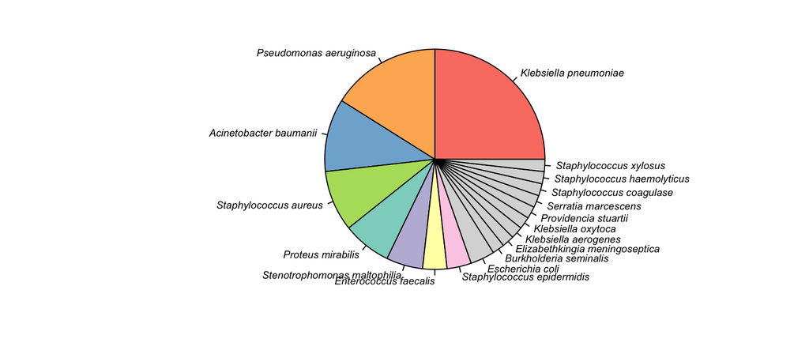

```r
pie2(path_freq[c(1:7, 9:8, 10:18), ])
```

First BSI episodes:

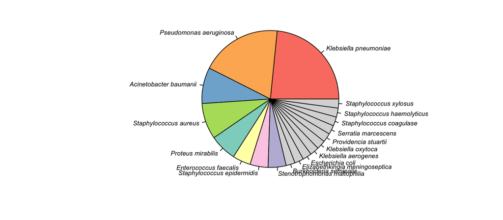

```r
pie2(path_freq_1step)
```

CLBSI (first) episodes:

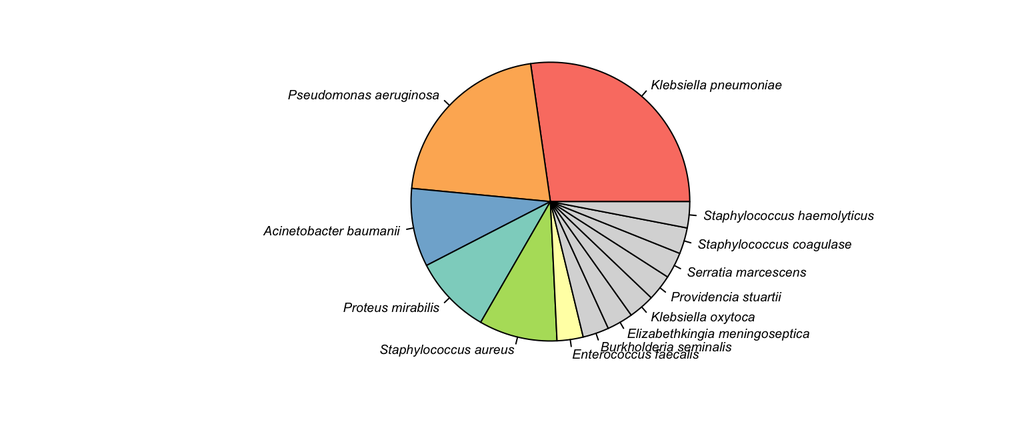

```r
pie2(path_freq_1stCLBSI[c(1:5, 8, 6:7, 9:13), ])
```

ALBSI (first) episodes:

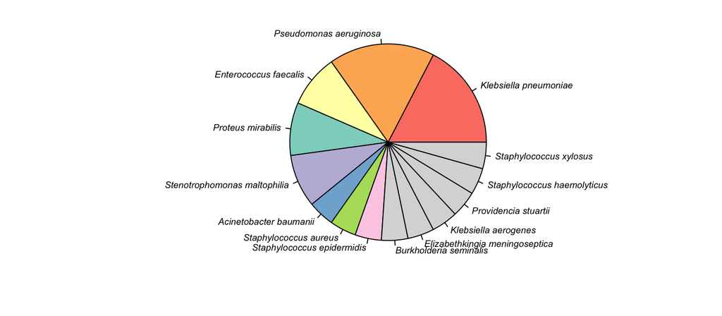

```r
pie2(path_freq_1stALBSI[c(1:6, 11:12, 7:10, 13:14), ])
```

Non-CLBSI (first) episodes:

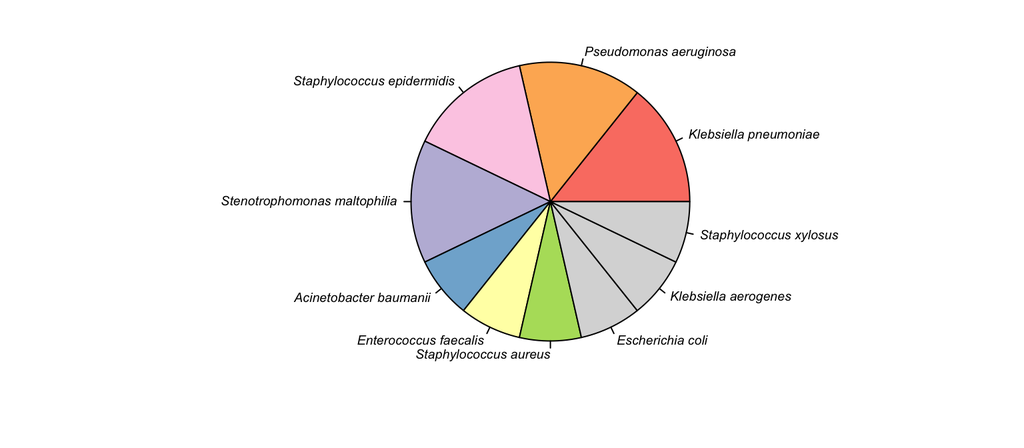

```r
pie2(path_freq_nonCLBSI[c(1:6, 9, 7:8, 10), ])
```

### Comparing distributions

Let’s now compare the distribution of the main bugs which are the following:

```r
main_bugs <- c("Klebsiella pneumoniae",  "Pseudomonas aeruginosa",
               "Acinetobacter baumanii", "Staphylococcus aureus",
               "Enterococcus faecalis")
```

The following function tests the difference in the prevalence of one bug `x` in the 5 different set-ups considered above (all BSI, first BSI episodes, etc…):

This function extracts the frequency of pathogen `y` in table `x`:

```r
  getx <- function(x, y) {
    x %>%
      filter(pathogens == y) %>%
      select(frequency) %>%
      unlist()
  }
```

This function extracts the total number of episodes in table `x`:

```r
  getn <- function(x) {
    x %>%
      select(nb_episodes) %>%
      first() %>%
      first()
  }
```

Let’s put all the pathogens tables into a list:

```r
table_list <- list(path_freq, path_freq_1step, path_freq_1stCLBSI, path_freq_1stALBSI, path_freq_nonCLBSI)
```

```r
fisher_test <- function(x) {
  c(function(y) getx(y, x), getn) %>%
    map(function(f) map(table_list, f)) %>%
    unlist() %>%
    matrix(nrow = 2, byrow = TRUE) %>%
    fisher.test() %>%
    use_series(p.value)
}
```

Let’s apply it to all the main bugs:

```r
map(main_bugs, fisher_test) %>%
  unlist() %>%
  setNames(main_bugs)
```

```
##  Klebsiella pneumoniae Pseudomonas aeruginosa Acinetobacter baumanii  Staphylococcus aureus  Enterococcus faecalis
##              0.9489319              0.9974445              0.9697294              0.9910660              0.7684983
```

The following function computes the proportion of a bug `x`, with 95%-confidence interval:

```r
calc_prop <- function(x) {
  map2(map(table_list, getx, x),
       map(table_list, getn),
       function(x, n) unlist(prop.test(x, n)[c("estimate", "conf.int")])) %>%
    reduce(rbind) %>%
    as.data.frame()
}
```

Let’s apply it to all the main bugs:

```r
prop_est <- map(main_bugs, calc_prop)
```

The following function puts together estimates (`x = 1`), lower bound (`x = 2`), or upper bound (`x = 3`) of an object of the `prop_est` object:

```r
extract3 <- function(x) {
  prop_est %>%
    map(extract2, x) %>%
    reduce(cbind)
}
```

Let’s apply it for estimates, lower and upper bounds:

```r
prop_est2 <- map(1:3, extract3)
```

Let’s draw the barplot:

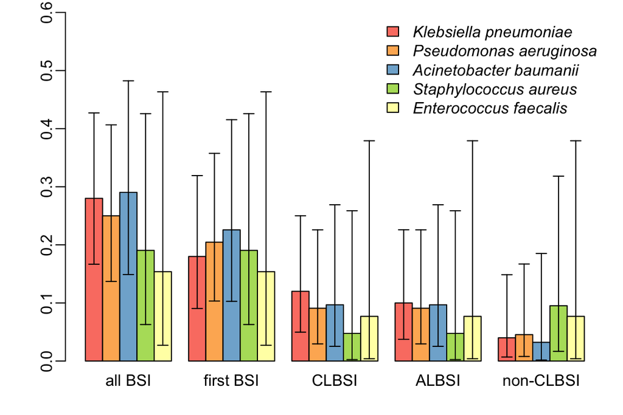

```r
barplot(prop_est2[[1]], beside = TRUE, col = colors[main_bugs], ylim = c(0, .6),
        names.arg = c("all BSI", "first BSI", "CLBSI", "ALBSI", "non-CLBSI"))
xs <- (2:30 - .5)[-seq(6, by = 6, le = 4)]
arrows(xs, as.numeric(prop_est2[[2]]), xs, as.numeric(prop_est2[[3]]), .05, 90, 3)
legend("topright", legend = main_bugs, fill = colors[main_bugs], bty = "n", text.font = 3)
```

## 5. Derivation of BSI incidence rate

The following function extracts estimate and confidence interval from the output of `prop.test()`:

```r
extract_prop_test <- function(x) {
  unname(unlist(x[c("estimate", "conf.int")]))
}
```

The following function puts in good shape the estimate and confidence interval:

```r
put_in_shape <- function(x) {
  paste0(x[1], " (", x[2], ", ", x[3], ")")
}
```

The following function uses the 2 preceding functions to calculate proportions:

```r
calc_prop <- function(x, factor, digits) {
  x %>%
    as.list() %>%
    reduce(prop.test) %>%
    extract_prop_test() %>%
    multiply_by(factor) %>%
    round(digits) %>%
    put_in_shape() %>%
    paste0(" (", paste(x, collapse = " / "), ")")
}
```

### HABSI rate

The following function calculates HA BSI rates, with confidence interval:

```r
habsi_rate <- function(x, factor = 1000, digits = 2) {
  x %>%
    select(habsi, rand2icu) %>%
    drop_na() %>%
    summarise_all(sum) %>%
    unlist() %>%
    calc_prop(factor, digits)
}
```

Let’s try it:

```r
habsi_rate(data2)
```

```
## [1] "3.76 (2.77, 5.1) (44 / 11688)"
```

### Proportion of patients with HABSI

The following function calculates the proportion of patients with HA BSI, with confidence interval:

```r
habsi_prop <- function(x, factor = 100, digits = 1) {
  x %>%
    select(habsi) %>%
    drop_na() %>%
    group_by(habsi) %>% # habsi is boolean
    tally() %>%
    add_column(total = sum(.$n)) %>%
    mutate(n = ifelse(habsi, n, total)) %>%
    pull(n) %>%
    rev() %>%
    calc_prop(factor, digits)
}
```

Let’s try it:

```r
habsi_prop(data2)
```

```
## [1] "7.4 (5.5, 9.9) (44 / 591)"
```

### Number of central line days

The following function calculates the number of CL days:

```r
nb_cl_days_fct <- function(x) {
  sum(x$nb_cl_days, na.rm = TRUE) %>%
    as.numeric() %>%
    as.character()
}
```

Let’s try it:

```r
nb_cl_days_fct(data2)
```

```
## [1] "3677"
```

### Central line utilization ratio

The following function calculates the CL utilization ratio:

```r
cl_utilization_ratio <- function(x, factor = 1000, digits = 2) {
  x %>%
    select(nb_cl_days, rand2icu) %>%
    drop_na() %>%
    summarise_all(sum) %>%
    unlist() %>%
    calc_prop(factor, digits)
}
```

Let’s try it:

```r
cl_utilization_ratio(data2)
```

```
## [1] "312.89 (304.5, 321.39) (3657 / 11688)"
```

### CLBSI rate

The following function calculates the CL BSI rate:

```r
clbsi_rate <- function(x, factor = 1000, digits = 2) {
  x %>%
    select(CLBSI, nb_cl_days) %>%
    drop_na() %>%
    summarise_all(sum) %>%
    unlist() %>%
    calc_prop(factor, digits)
}
```

Let’s try it:

```r
clbsi_rate(data2)
```

```
## [1] "8.43 (5.83, 12.1) (31 / 3677)"
```

#### Putting together

The following function generates 1 row of the final table:

```r
make1row <- function(x) {
    map(list(habsi_rate, habsi_prop, nb_cl_days_fct, cl_utilization_ratio, clbsi_rate), function(f) f(x)) %>%
    as_data.frame() %>%
    unname()
}
```

Let’s try it:

```r
make1row(data2)
```

```
##
## 1 3.76 (2.77, 5.1) (44 / 11688) 7.4 (5.5, 9.9) (44 / 591) 3677 312.89 (304.5, 321.39) (3657 / 11688) 8.43 (5.83, 12.1) (31 / 3677)
```

The following is a wrapper around the previous one and applies it by group:

```r
make1group <- function(x) {
  data2 %>%
    filter(! is.na(.[[x]])) %>%
    group_by(.[[x]]) %>%
    group_modify(~ make1row(.x)) %>%
    ungroup()
}
```

Let’s try it:

```r
make1group("hospital")
```

```
## # A tibble: 3 x 6
##   `.[[x]]` V1                            V2                         V3    V4                                    V5
##   <chr>    <chr>                         <chr>                      <chr> <chr>                                 <chr>
## 1 BVTV     4.16 (2.12, 7.91) (10 / 2403) 7.4 (3.8, 13.6) (10 / 135) 946   385.35 (365.88, 405.19) (926 / 2403)  9.51 (4.65, 18.67) (9 / 946)
## 2 HTD      3.52 (2.28, 5.36) (23 / 6539) 7.8 (5.1, 11.7) (23 / 294) 1260  192.69 (183.24, 202.51) (1260 / 6539) 10.32 (5.75, 18.07) (13 / 1260)
## 3 NHTD     4.01 (2.11, 7.39) (11 / 2746) 6.8 (3.6, 12.1) (11 / 162) 1471  535.69 (516.82, 554.46) (1471 / 2746) 6.12 (2.99, 12.03) (9 / 1471)
```

let’s consider the following groups:

```r
groups <- c("hospital", "Tetanus", "ALBSI", "tracheostomy", "deathICU", "death28", "death90")
```

This will be the names of the columns in the final data frame:

```r
col_names <- c("group", "HABSI rate", "proportion of HABSI", "# CL days", "CL utilization ratio", "CLBSI rate")
```

Let’s compute the statistics for all the groups:

```r
out <- map(groups, make1group) %>%
  c(list(as_data.frame(c("all", make1row(data2)))), .) %>%
  lapply(setNames, col_names) %>%
  lapply(mutate_at, 1, as.character)
```

The intermediate titles:

```r
inter <- lapply(groups, function(x) {
                          x %>%
                            c(rep("", 5)) %>%
                            t() %>%
                            as_data.frame() %>%
                            setNames(col_names)
                        })
```

let’s put everything together:

```r
lapply(1:7, function(x) c(out[x], inter[x])) %>%
  unlist(FALSE) %>%
  c(out[8]) %>%
  bind_rows()
```

```
##           group                      HABSI rate        proportion of HABSI # CL days                   CL utilization ratio                      CLBSI rate
## 1           all   3.76 (2.77, 5.1) (44 / 11688)  7.4 (5.5, 9.9) (44 / 591)      3677  312.89 (304.5, 321.39) (3657 / 11688)   8.43 (5.83, 12.1) (31 / 3677)
## 2      hospital
## 3          BVTV   4.16 (2.12, 7.91) (10 / 2403) 7.4 (3.8, 13.6) (10 / 135)       946   385.35 (365.88, 405.19) (926 / 2403)    9.51 (4.65, 18.67) (9 / 946)
## 4           HTD   3.52 (2.28, 5.36) (23 / 6539) 7.8 (5.1, 11.7) (23 / 294)      1260  192.69 (183.24, 202.51) (1260 / 6539) 10.32 (5.75, 18.07) (13 / 1260)
## 5          NHTD   4.01 (2.11, 7.39) (11 / 2746) 6.8 (3.6, 12.1) (11 / 162)      1471  535.69 (516.82, 554.46) (1471 / 2746)   6.12 (2.99, 12.03) (9 / 1471)
## 6       Tetanus
## 7         FALSE   3.06 (1.97, 4.71) (22 / 7192)  5.4 (3.5, 8.1) (22 / 411)      2358  325.08 (314.28, 336.07) (2338 / 7192)     8.06 (5, 12.81) (19 / 2358)
## 8          TRUE   4.89 (3.15, 7.53) (22 / 4496)  12.2 (8, 18.1) (22 / 180)      1319  293.37 (280.13, 306.97) (1319 / 4496)   9.1 (4.94, 16.31) (12 / 1319)
## 9         ALBSI
## 10        FALSE  2.08 (1.35, 3.17) (23 / 11066)    4 (2.6, 6.1) (23 / 570)      3579 321.62 (312.93, 330.42) (3559 / 11066)   4.75 (2.86, 7.77) (17 / 3579)
## 11         TRUE 33.76 (21.55, 52.02) (21 / 622)           NA (NA, NA) (21)        98      157.56 (130.3, 189.14) (98 / 622) 142.86 (83.1, 231.46) (14 / 98)
## 12 tracheostomy
## 13        FALSE  7.06 (4.58, 10.75) (23 / 3260) 17 (11.3, 24.7) (23 / 135)       555   170.25 (157.58, 183.69) (555 / 3260) 27.03 (15.76, 45.21) (15 / 555)
## 14         TRUE    1.5 (0.81, 2.69) (12 / 8018)  2.7 (1.5, 4.8) (12 / 441)      3052  378.15 (367.53, 388.88) (3032 / 8018)    2.29 (1.01, 4.95) (7 / 3052)
## 15     deathICU
## 16        FALSE   3.04 (2.06, 4.45) (28 / 9210)     7 (4.8, 10) (28 / 402)      2492     268.4 (259.4, 277.6) (2472 / 9210)   6.42 (3.8, 10.65) (16 / 2492)
## 17         TRUE  6.46 (3.82, 10.71) (16 / 2478) 8.5 (5.1, 13.6) (16 / 189)      1185   478.21 (458.39, 498.1) (1185 / 2478)  12.66 (7.37, 21.3) (15 / 1185)
## 18      death28
## 19        FALSE  3.44 (2.44, 4.81) (36 / 10475) 8.7 (6.2, 11.9) (36 / 415)      2878  272.84 (264.35, 281.5) (2858 / 10475)  8.34 (5.47, 12.59) (24 / 2878)
## 20         TRUE     6.6 (3.07, 13.5) (8 / 1213)   4.5 (2.1, 9.1) (8 / 176)       799    658.7 (631.13, 685.24) (799 / 1213)    8.76 (3.84, 18.81) (7 / 799)
## 21      death90
## 22        FALSE    3.09 (2.1, 4.53) (28 / 9052) 7.5 (5.1, 10.8) (28 / 373)      2446  268.01 (258.93, 277.28) (2426 / 9052)  6.54 (3.87, 10.85) (16 / 2446)
## 23         TRUE   6.07 (3.6, 10.07) (16 / 2636) 7.3 (4.4, 11.9) (16 / 218)      1231     467 (447.82, 486.27) (1231 / 2636) 12.19 (7.09, 20.51) (15 / 1231)
```

## 6. Risk factors associated with BSI

### Utilitary functions

The following function transforms a continuous variable into a categorical variable with equal amount of data in each category:

```r
makecat <- function(x, n = 3) {
  cut(x, quantile(x, seq(0, 1, le = n + 1), TRUE), include.lowest = TRUE)
}
```

Prints nice outputs for percentages:

```r
n_and_perc <- function(x, y) {
  paste0(x, " (", y, " %)")
}
```

The following function adds a single blank to each element of a list:

```r
add_single_blanks <- function(x) {
  x %>%
    map(~ c("", .x)) %>%
    unlist()
}
```

The following function extract the $p$-values of each level of each variable of a Cox regression model `x`:

```r
extract_levels_pvalues <- function(x) {
  x %>%
    summary() %>%
    use_series("coefficient") %>%
    magrittr::extract(, "Pr(>|z|)")
}
```

### Risk factors

The following function computes the risk factors table:

```r
risk_factors <- function(event, time, digit1 = 1, digits = 3) {
# Making the data:
  data <- data2 %>%
    select({{event}}, Sex, age, hospital, apache, charlson, sepsis, Tetanus, CNS,
           dia_co, Mode, had_catheter, had_arterial, tracheostomy, adm2icu, {{time}}) %>%
    mutate_at("adm2icu", as.numeric) %>%
    mutate_at(vars(age, adm2icu, apache), makecat)

# Adding habsi in case not in:
  if (! "habsi" %in% names(data)) data$habsi <- data2$habsi

# Generating variables sets:
  event_time <- data %>%
    select({{event}}, {{time}}) %>%
    names()
  event_var <- event_time[1]
  time_var <- event_time[2]
  variables <- setdiff(names(data), event_time)

# The following function gives numbers and percentages:
  n_and_percentage <- function(var) {
    x <- as.numeric(table(data[[var]], data[[event_var]]))
    map2(x, round(100 * x / sum(x), digit1), n_and_perc) %>%
      unlist() %>%
      matrix(ncol = 2)
  }

# The numbers and percentages for all the variables:
  numbers <- lapply(variables, n_and_percentage) %>%
    reduce(rbind)

# The following function uses a function f on all the variables and adds space
# between each variable:
  calc_uni_single <- function(f) {
    variables %>%
      lapply(f) %>%
      add_single_blanks()
  }

# The following function extracts the coefficients of a Cox regression and puts
# them into shape:
  cox_coef <- function(x) {
    y <- Surv(data[[time_var]], data[[event_var]])
    coxph(y ~ data[[x]]) %>%
      (function(x) map(c(coef, confint), function(f) f(x))) %>%
      reduce(cbind) %>%
      exp() %>%
      round(digits) %>%
      apply(1, put_in_shape) %>%
      as.matrix()
  }

# The following function runs a Cox regression and extracts the p-values for
# each level of each variable:
  cox_p1 <- function(x) {
    y <- Surv(data[[time_var]], data[[event_var]])
    coxph(y ~ data[[x]]) %>%
      extract_levels_pvalues() %>%
      round(digits)
  }

# The following function runs a Cox regression and extracts the p-values for
# each variable:
  cox_p2 <- function(x) {
    y <- Surv(data[[time_var]], data[[event_var]])
    coxph(y ~ data[[x]]) %>%
      anova() %>%
      extract2("Pr(>|Chi|)") %>%
      magrittr::extract(2) %>%
      round(digits)
  }

# The number of levels per variable:
  nb_lev <- sapply(variables, function(x) length(unique(na.exclude(data[[x]]))))

# The function that adds the blanks:
  add_multiple_blanks <- function(x) {
    blanks <- map(nb_lev - 1, ~ rep("", .x))
    map2(x, blanks, ~ c(.x, .y))
  }

# The p-values of each variable from univariate models:
  p_uni2 <- variables %>%
    sapply(cox_p2) %>%
     add_multiple_blanks() %>%
     unlist()

# The multivariate model:
  m <- coxph(Surv(data[[time_var]], data[[event_var]]) ~ ., data[, variables])

# The following function splits a data frame by variables, according to the
# number of levels in each variable:
  split_by_variable <- function(x) {
    split(x, rep(seq_along(nb_lev), nb_lev - 1))
  }

# Coefficients of the multivariate model:
  c_multi <- m %>%
    (function(x) map(c(coef, confint), function(f) f(x))) %>%
    reduce(cbind) %>%
    exp() %>%
    round(digits) %>%
    apply(1, put_in_shape) %>%
    split_by_variable() %>%
    map(~ c("", .x)) %>%
    unlist()

# p-values of each level of each variable of the multivariate model:
  p_multi1 <- m %>%
    extract_levels_pvalues() %>%
    round(digits) %>%
    split_by_variable() %>%
    add_single_blanks()

# p-values of each variable of the multivariate model, corrected for confoundings:
  p_multi2 <- m %>%
    car::Anova(test = "LR") %>%
    extract2("Pr(>Chisq)") %>%
    round(digits) %>%
    add_multiple_blanks() %>%
    unlist()

# Levels:
  levels <- data[, variables] %>%
    mutate_all(as.factor) %>%
    lapply(levels) %>%
    unlist()

# variables:
  vars <- variables %>%
    add_multiple_blanks %>%
    unlist()

# Putting together:
  cbind(vars, levels, numbers, calc_uni_single(cox_coef),
        calc_uni_single(cox_p1), p_uni2, c_multi, p_multi1, p_multi2) %>%
    as_data.frame() %>%
    remove_rownames() %>%
    setNames(c("variables", "levels", "non event", "event", "rate ratio uni",
               "p level 1", "p variable 1", "rate ratio multi", "p level 2", "p variable 2 "))
}
```

Let’s run it:

```r
risk_factors(habsi, time2bsi)
```

```
##       variables   levels    non event      event       rate ratio uni p level 1 p variable 1      rate ratio multi p level 2 p variable 2
## 1           Sex   Female 173 (29.3 %) 10 (1.7 %)                                       0.078                                         0.182
## 2                   Male 374 (63.3 %) 34 (5.8 %) 1.838 (0.903, 3.741)     0.093               1.964 (0.697, 5.536)     0.202
## 3           age  [17,47] 191 (32.3 %) 13 (2.2 %)                                       0.474                                         0.835
## 4                (47,65] 182 (30.8 %) 11 (1.9 %) 1.028 (0.458, 2.307)     0.947               1.078 (0.375, 3.095)     0.889
## 5               (65,104] 174 (29.4 %) 20 (3.4 %) 1.473 (0.731, 2.969)     0.279               1.344 (0.478, 3.783)     0.575
## 6      hospital     BVTV 125 (21.2 %) 10 (1.7 %)                                       0.792                                         0.002
## 7                    HTD 271 (45.9 %) 23 (3.9 %) 0.782 (0.371, 1.649)     0.519               0.153 (0.014, 1.644)     0.121
## 8                   NHTD 151 (25.5 %) 11 (1.9 %) 0.915 (0.385, 2.176)      0.84               2.057 (0.351, 12.04)     0.424
## 9        apache   [4,15] 198 (34.1 %) 21 (3.6 %)                                       0.334                                         0.288
## 10               (15,20] 160 (27.5 %)  9 (1.5 %)    0.59 (0.27, 1.29)     0.186                 1.01 (0.346, 2.95)     0.986
## 11               (20,40] 179 (30.8 %) 14 (2.4 %) 1.001 (0.507, 1.974)     0.999               2.574 (0.668, 9.916)     0.169
## 12     charlson (-Inf,0] 333 (56.3 %) 28 (4.7 %)                                       0.167                                           0.2
## 13                 (0,2] 128 (21.7 %)  5 (0.8 %)  0.637 (0.246, 1.65)     0.353               0.561 (0.161, 1.954)     0.364
## 14                 (2,4]   38 (6.4 %)    6 (1 %) 2.324 (0.957, 5.641)     0.062              3.454 (0.693, 17.208)      0.13
```

[output cut: 20 more lines]

## 7. Risk factors associated with mortality

Same function as before, with different event:

```r
risk_factors(death90, DOD)
```

```
##       variables   levels    non event        event       rate ratio uni p level 1 p variable 1     rate ratio multi p level 2 p variable 2
## 1           Sex   Female 114 (19.3 %)  69 (11.7 %)                                       0.863                                        0.785
## 2                   Male 259 (43.8 %) 149 (25.2 %) 0.975 (0.733, 1.297)     0.863              1.049 (0.743, 1.482)     0.785
## 3           age  [17,47] 137 (23.2 %)  67 (11.3 %)                                        0.21                                        0.645
## 4                (47,65] 122 (20.6 %)    71 (12 %)   1.16 (0.831, 1.62)     0.384              1.056 (0.698, 1.597)     0.796
## 5               (65,104] 114 (19.3 %)  80 (13.5 %) 1.339 (0.968, 1.853)     0.078               1.23 (0.777, 1.947)     0.377
## 6      hospital     BVTV  66 (11.2 %)  69 (11.7 %)                                           0                                        0.005
## 7                    HTD 224 (37.9 %)  70 (11.8 %) 0.372 (0.267, 0.519)         0              0.672 (0.387, 1.169)      0.16
## 8                   NHTD    83 (14 %)  79 (13.4 %) 0.945 (0.684, 1.306)     0.733              1.382 (0.847, 2.257)     0.195
## 9        apache   [4,15] 185 (31.8 %)   34 (5.9 %)                                           0                                        0.002
## 10               (15,20]  96 (16.5 %)  73 (12.6 %)  3.276 (2.18, 4.923)         0               1.67 (1.023, 2.725)      0.04
## 11               (20,40]  85 (14.6 %) 108 (18.6 %) 4.828 (3.281, 7.103)         0               2.363 (1.43, 3.903)     0.001
## 12     charlson (-Inf,0] 258 (43.7 %) 103 (17.4 %)                                           0                                            0
## 13                 (0,2]    77 (13 %)   56 (9.5 %) 1.658 (1.197, 2.295)     0.002              1.456 (0.965, 2.195)     0.073
## 14                 (2,4]   24 (4.1 %)   20 (3.4 %) 1.748 (1.083, 2.823)     0.022               1.34 (0.687, 2.612)      0.39
```

[output cut: 22 more lines]

## 8. Kaplan–Meier analysis

### The data

Here are the variables we need:

```r
data3 <- data2 %>%
  select(habsi, DOD, rand2hos, deathICU, death28, death90, CLBSI) %>%
  mutate(timeICU = as.integer(rand2hos),
         time28  = ifelse(DOD < 29, DOD, 28),
         time90  = DOD) %>%
  select(-DOD, -rand2hos)
```

Which looks like this:

```r
data3
```

```
## # A tibble: 591 x 8
##    habsi deathICU death28 death90 CLBSI timeICU time28 time90
##    <lgl> <lgl>    <lgl>   <lgl>   <lgl>   <int>  <dbl>  <int>
##  1 FALSE FALSE    FALSE   FALSE   FALSE      11     28     90
##  2 FALSE FALSE    FALSE   TRUE    FALSE      23     28     58
##  3 FALSE FALSE    FALSE   FALSE   FALSE      NA     28     90
##  4 FALSE FALSE    FALSE   FALSE   FALSE      14     28     90
##  5 FALSE TRUE     TRUE    TRUE    FALSE      NA      1      1
##  6 FALSE TRUE     TRUE    TRUE    FALSE      NA     19     19
##  7 FALSE FALSE    FALSE   FALSE   FALSE      13     28     90
##  8 FALSE FALSE    FALSE   FALSE   FALSE      23     28     90
##  9 FALSE TRUE     TRUE    TRUE    FALSE       1      2      2
## 10 FALSE FALSE    FALSE   FALSE   FALSE      17     28     90
## # … with 581 more rows
```

### Tables of contingency

The distributions of events as functions of HA BSI:

```r
with(data3, table(habsi, deathICU))
```

```
##        deathICU
## habsi   FALSE TRUE
##   FALSE   374  173
##   TRUE     28   16
```

```r
with(data3, table(habsi, death28))
```

```
##        death28
## habsi   FALSE TRUE
##   FALSE   379  168
##   TRUE     36    8
```

```r
with(data3, table(habsi, death90))
```

```
##        death90
## habsi   FALSE TRUE
##   FALSE   345  202
##   TRUE     28   16
```

The distributions of events as functions of CL BSI:

```r
with(data3, table(CLBSI, deathICU))
```

```
##        deathICU
## CLBSI   FALSE TRUE
##   FALSE   386  174
##   TRUE     16   15
```

```r
with(data3, table(CLBSI, death28))
```

```
##        death28
## CLBSI   FALSE TRUE
##   FALSE   391  169
##   TRUE     24    7
```

```r
with(data3, table(CLBSI, death90))
```

```
##        death90
## CLBSI   FALSE TRUE
##   FALSE   357  203
##   TRUE     16   15
```

And the relationship between HA BSI and CL BSI:

```r
with(data3, table(CLBSI, habsi))
```

```
##        habsi
## CLBSI   FALSE TRUE
##   FALSE   547   13
##   TRUE      0   31
```

### Utilitary functions

This function splits a vector `x` according to the indexes given by the vector `pos`:

```r
splitat <- function(x, pos) {
  split(x, cumsum(seq_along(x) %in% pos))
}
```

This functions transform a vector of $x$ coordinates so that it can easily be plotted in staircase style:

```r
transform_x <- function(x, at) {
  tmp <- splitat(x, at)
  time2 <- tmp[-1] %>%
    map(~ c(first(.x), .x)) %>%
    c(first(tmp), .) %>%
    unlist()

}
```

This functions transform a vector of $y$ coordinates so that it can easily be plotted in staircase style:

```r
transform_y <- function(x, at) {
  tmp <- splitat(x, at)
  tmp[-length(tmp)] %>%
    map(~ c(.x, last(.x))) %>%
    c(last(tmp)) %>%
    unlist()
}
```

### A function to plot events occurences

```r
plotevent <- function(a, ylim = 0:1, col_line = "black", col_area = "grey", add = FALSE) {

  snames <- c("time", "surv", "lower", "upper")

  tmp <- a %>%
    unclass() %>%
    magrittr::extract(snames) %>%
    map2(c(0, 1, 1, 1), ~ c(.y, .x))

  sel <- with(tmp, sort(c(which(! near(diff(lower), 0)), which(! near(diff(upper), 0))) + 1))

  c(transform_x, transform_y, transform_y, transform_y) %>%
    map2(tmp, ~ .x(.y, sel)) %>%
    setNames(snames) %>%
    with({
      if (! add) plot(time, 1 - surv, xlab = "time (days)", ylab = "proportion dead", ylim = ylim, type = "n")
      polygon(c(time, rev(time)), 1 - c(lower, rev(upper)), col = col_area, border = NA)
      lines(time, 1 - surv, col = col_line)
    })
}
```

### Events occurences as functions of time

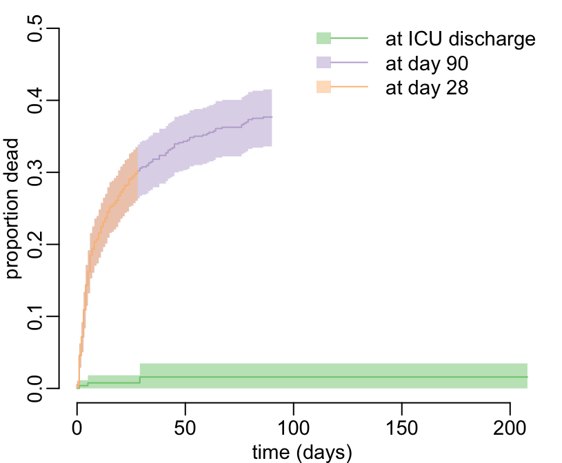

```r
colors <- c("#7fc97f", "#beaed4", "#fdc086")
adjcol <- adjustcolor(colors, .5)
ylim <- c(0, .5)
plotevent(survfit(Surv(timeICU, deathICU) ~ 1, data = data3), ylim, colors[1], adjcol[1])
plotevent(survfit(Surv(time90 , death90)  ~ 1, data = data3), ylim, colors[2], adjcol[2], add = TRUE)
plotevent(survfit(Surv(time28 , death28)  ~ 1, data = data3), ylim, colors[3], adjcol[3], add = TRUE)
legend("topright", legend = c("at ICU discharge", "at day 90", "at day 28"),
       fill = adjcol, col = colors, lty = 1, bty = "n", border = NA)
```

### Events occurences as functions of time and BSI status

Graph parameters:

```r
colors <- c("#e41a1c", "#377eb8")
adjcol <- adjustcolor(colors, .5)
add_legend <- function() {
  legend("topleft", legend = c("HA BSI", "non HA BSI"), fill = adjcol, col = colors, lty = 1, bty = "n", border = NA)
}
```

Death at ICU:

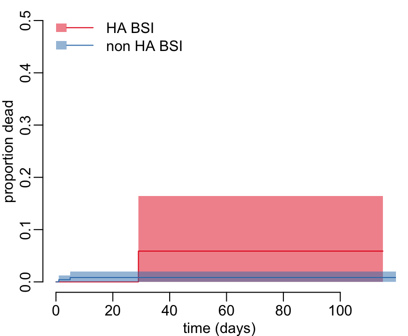

```r
plotevent(survfit(Surv(timeICU, deathICU) ~ 1, data = filter(data3,   habsi)), ylim, colors[1], adjcol[1])
plotevent(survfit(Surv(timeICU, deathICU) ~ 1, data = filter(data3, ! habsi)), ylim, colors[2], adjcol[2], add = TRUE)
add_legend()
```

Death at day 28:

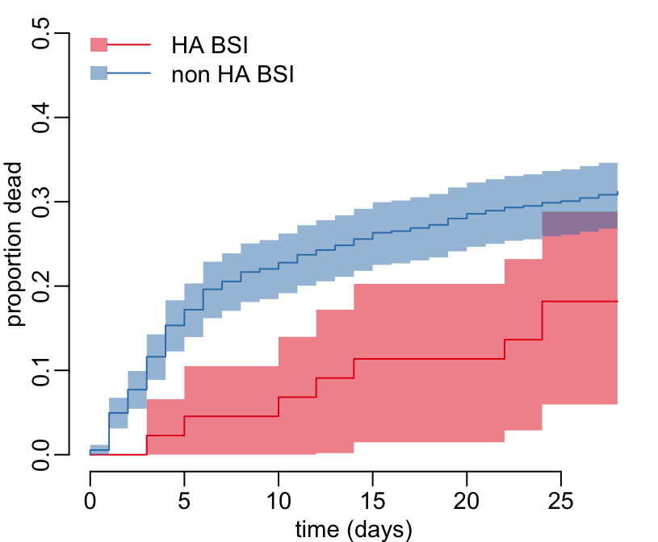

```r
plotevent(survfit(Surv(time28, death28) ~ 1, data = filter(data3,   habsi)), ylim, colors[1], adjcol[1])
plotevent(survfit(Surv(time28, death28) ~ 1, data = filter(data3, ! habsi)), ylim, colors[2], adjcol[2], add = TRUE)
add_legend()
```

Death at day 90:

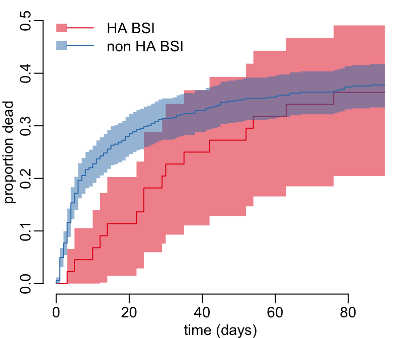

```r
plotevent(survfit(Surv(time90, death90) ~ 1, data = filter(data3,   habsi)), ylim, colors[1], adjcol[1])
plotevent(survfit(Surv(time90, death90) ~ 1, data = filter(data3, ! habsi)), ylim, colors[2], adjcol[2], add = TRUE)
add_legend()
```

### Events occurences as functions of time and type of BSI status

```r
colors <- c("#377eb8", "#984ea3", "#ff7f00")
adjcol <- adjustcolor(colors, .5)
ylim <- c(0, .7)
add_legend <- function() {
  legend("topleft", legend = c("non HA BSI", "CLBSI", "non CL BSI"), fill = adjcol, col = colors, lty = 1, bty = "n", border = NA)
}
```

Death at ICU:

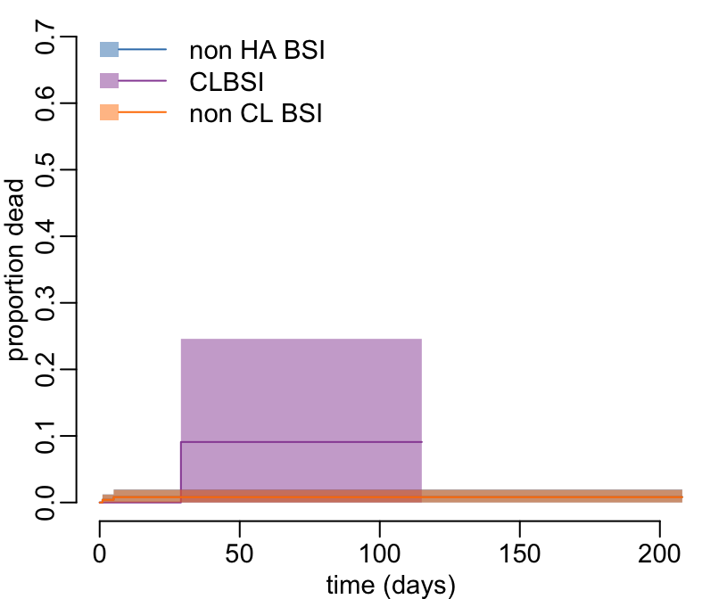

```r
plotevent(survfit(Surv(timeICU, deathICU) ~ 1, data = filter(data3, ! habsi)), ylim, colors[1], adjcol[1])
plotevent(survfit(Surv(timeICU, deathICU) ~ 1, data = filter(data3,   CLBSI)), ylim, colors[2], adjcol[2], add = TRUE)
plotevent(survfit(Surv(timeICU, deathICU) ~ 1, data = filter(data3, ! CLBSI)), ylim, colors[3], adjcol[3], add = TRUE)
add_legend()
```

Death at day 28:

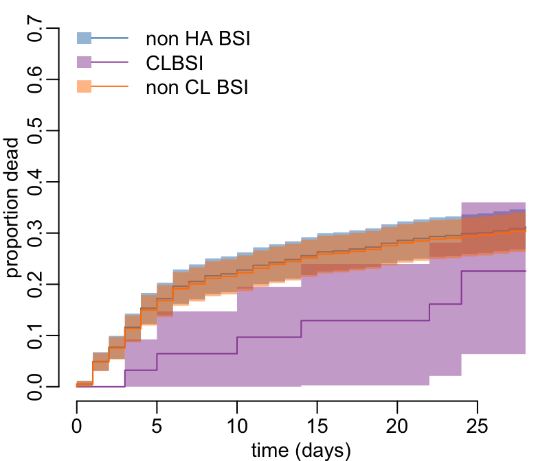

```r
plotevent(survfit(Surv(time28, death28) ~ 1, data = filter(data3, ! habsi)), ylim, colors[1], adjcol[1])
plotevent(survfit(Surv(time28, death28) ~ 1, data = filter(data3,   CLBSI)), ylim, colors[2], adjcol[2], add = TRUE)
plotevent(survfit(Surv(time28, death28) ~ 1, data = filter(data3, ! CLBSI)), ylim, colors[3], adjcol[3], add = TRUE)
add_legend()
```

Death at day 90:

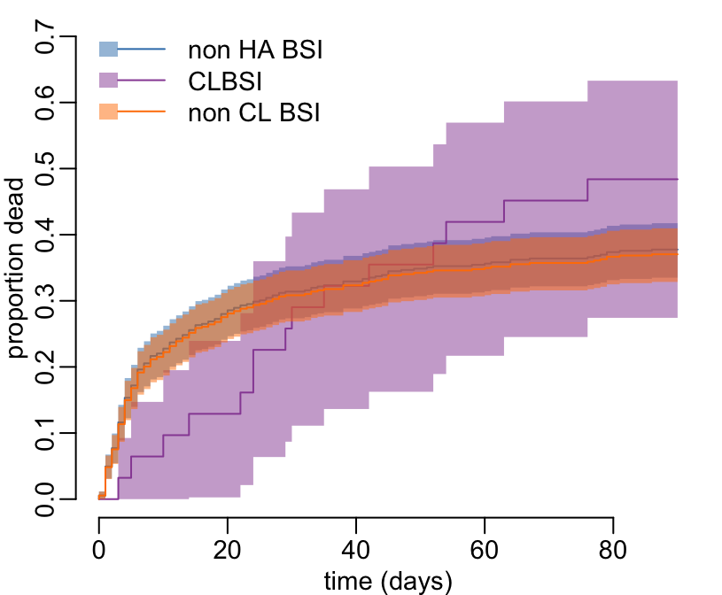

```r
plotevent(survfit(Surv(time90, death90) ~ 1, data = filter(data3, ! habsi)), ylim, colors[1], adjcol[1])
plotevent(survfit(Surv(time90, death90) ~ 1, data = filter(data3,   CLBSI)), ylim, colors[2], adjcol[2], add = TRUE)
plotevent(survfit(Surv(time90, death90) ~ 1, data = filter(data3, ! CLBSI)), ylim, colors[3], adjcol[3], add = TRUE)
add_legend()
```